# Neonate Data Analysis Colorado 2022

Robin Bedard & Savannah Weaver

# Packages

```r
library("tidyverse") # for dplyr workflow + ggplot
library("rmdformats") # pretty Rmd format
library("lme4")
library("lmerTest")
library("emmeans")
library("broom")
library("AICcmodavg")
library("ggpubr")
```

# Fig Theme

```r
my_ggplot_theme <- theme_classic() + # start with a preset theme to make things easy
                     theme(axis.title = element_text(size = 10), # text size for axis labels
                           axis.text = element_text(size = 8, # text size for axis values
                                                    color = "black", # need to specifically set color
                                                    family = "sans"), # and family
                           legend.title = element_text(size = 8), # text size for the legend title
                           legend.text = element_text(size = 8), # text size for legend items
                           text = element_text(color = "black", # color for all text (except axis values)
                                               family = "sans") # family
                           )
```

Now, apply the theme. This sets the theme for the entire Rmd document.

```r
theme_set(my_ggplot_theme)
```

# Acronyms

DAB = day after birth PS = post-shed / 1 week after birth

# Load & Tidy Data

## DAB osmolality

This is the osmolality of each individual neonate the day after birth.

```r
neonate_dab_osmol <- readRDS("data/neonate_DAB_osmolality.RDS")
head(neonate_dab_osmol)
```

```
## # A tibble: 6 × 3
## # Groups:   CEWL_Blood_Collect_Date [1]
##   CEWL_Blood_Collect_Date Indiv_ID Plasma_Osmol_Rep_mean
##   <date>                  <fct>                    <dbl>
## 1 2022-08-28              300                        306
## 2 2022-08-28              301                        312
## 3 2022-08-28              302                        304
## 4 2022-08-28              303                        313
## 5 2022-08-28              304                        293
## 6 2022-08-28              305                        278
```

## DAB body size

This is the body size and body temperature at time of CEWL measurements for each individual neonate.

```r
neonate_dab_all0 <- readRDS("data/neonate_DAB_body_size.RDS")

neonate_dab_all <- neonate_dab_all0 %>%
  # fix a typo of where the decimal was put
  mutate(SVL_cm = case_when(SVL_cm == 2.4 ~ SVL_cm*10, TRUE ~ SVL_cm)) %>%
  rename(Date_Born_Shed = Date_Born) %>%
  mutate(timept = "DAB")

# robin removed this one...
#neonate_dab_all[77, ]

summary(neonate_dab_all)
```

```
##     Indiv_ID  Date_Born_Shed       Tail_Length_cm      SVL_cm
##  300    : 1   Min.   :2022-08-26   Min.   :1.200   Min.   :20.50
##  301    : 1   1st Qu.:2022-08-30   1st Qu.:1.600   1st Qu.:22.00
##  302    : 1   Median :2022-09-01   Median :1.900   Median :22.55
##  303    : 1   Mean   :2022-08-31   Mean   :1.829   Mean   :22.67
##  304    : 1   3rd Qu.:2022-09-04   3rd Qu.:2.000   3rd Qu.:23.15
##  305    : 1   Max.   :2022-09-05   Max.   :2.500   Max.   :25.70
##  (Other):76
##  Tail_SVL_Ratio        Mass_g     Sex      Mother_ID  Treatment   Tb_CEWL_c
##  Min.   :0.05330   Min.   :11.6   F:27   101    : 5   C:36      Min.   :25.80
##  1st Qu.:0.06825   1st Qu.:13.5   M:55   124    : 5   W:46      1st Qu.:27.23
##  Median :0.08480   Median :14.9          125    : 5             Median :28.25
##  Mean   :0.09035   Mean   :15.4          126    : 5             Mean   :28.23
##  3rd Qu.:0.09150   3rd Qu.:16.5          127    : 5             3rd Qu.:29.00
##  Max.   :0.87500   Max.   :23.0          128    : 5             Max.   :31.30
##                                          (Other):52
##  Pee    CEWL_Blood_Collect_Date    timept
##  N:39   Min.   :2022-08-28      Length:82
##  Y:43   1st Qu.:2022-08-31      Class :character
##         Median :2022-09-02      Mode  :character
##         Mean   :2022-09-01
##         3rd Qu.:2022-09-05
##         Max.   :2022-09-06
##
```

## PS lumped

```r
neonate_postshed <- readRDS("data/neonate_PS_all_data.RDS")
```

## PS osmolality

first, separate out and get mean osmolality per individual

```r
postshed_osmol <- neonate_postshed %>%
  select(CEWL_Blood_Collect_Date, Indiv_ID,
         Plasma_Osmol_Rep1, Plasma_Osmol_Rep2,
         Plasma_Osmol_Rep3, Plasma_Osmol_Rep4) %>%
  pivot_longer(3:6, names_to = "rep", values_to = "osml") %>%
  filter(complete.cases(osml)) %>%
  group_by(CEWL_Blood_Collect_Date, Indiv_ID) %>%
  summarise(Plasma_Osmol_Rep_mean = mean(osml))
head(postshed_osmol)
```

```
## # A tibble: 6 × 3
## # Groups:   CEWL_Blood_Collect_Date [1]
##   CEWL_Blood_Collect_Date Indiv_ID Plasma_Osmol_Rep_mean
##   <date>                  <fct>                    <dbl>
## 1 2022-09-03              303                       352
## 2 2022-09-03              304                       345
## 3 2022-09-03              344                       349
## 4 2022-09-03              345                       332.
## 5 2022-09-03              346                       344
## 6 2022-09-03              347                       428
```

## PS body size

```r
neonate_postshed_clean <- neonate_postshed %>%
  select(Indiv_ID, Date_Born_Shed = Date_Shed,
         CEWL_Blood_Collect_Date,
         Tail_Length_cm, SVL_cm, Tail_SVL_Ratio,
         Mass_g, Sex, Pee, Tb_CEWL_c,
         Mother_ID, Treatment) %>%
  mutate(timept = "PS") %>%
  # fix a typo
  mutate(Treatment = case_when(Mother_ID == 128 ~ "W", TRUE ~ Treatment)) %>%
  mutate(Treatment = factor(Treatment))
summary(neonate_postshed_clean)
```

```
##     Indiv_ID  Date_Born_Shed       CEWL_Blood_Collect_Date Tail_Length_cm
##  303    : 1   Min.   :2022-09-02   Min.   :2022-09-03      Min.   :1.50
##  304    : 1   1st Qu.:2022-09-02   1st Qu.:2022-09-03      1st Qu.:1.65
##  320    : 1   Median :2022-09-03   Median :2022-09-04      Median :1.90
##  344    : 1   Mean   :2022-09-03   Mean   :2022-09-04      Mean   :1.88
##  345    : 1   3rd Qu.:2022-09-04   3rd Qu.:2022-09-05      3rd Qu.:2.05
##  346    : 1   Max.   :2022-09-04   Max.   :2022-09-05      Max.   :2.30
##  (Other):29
##      SVL_cm      Tail_SVL_Ratio        Mass_g      Sex    Pee
##  Min.   :22.40   Min.   :0.06220   Min.   :11.10   F:13   N:29
##  1st Qu.:23.15   1st Qu.:0.06855   1st Qu.:12.05   M:22   Y: 6
##  Median :23.80   Median :0.08160   Median :13.00
##  Mean   :23.87   Mean   :0.07881   Mean   :13.42
##  3rd Qu.:24.00   3rd Qu.:0.08665   3rd Qu.:14.40
##  Max.   :26.50   Max.   :0.09750   Max.   :19.00
##
##    Tb_CEWL_c       Mother_ID Treatment    timept
##  Min.   :26.50   125    :5   C:19      Length:35
##  1st Qu.:27.75   128    :5   W:16      Class :character
##  Median :28.50   133    :5             Mode  :character
##  Mean   :28.63   134    :5
##  3rd Qu.:29.55   135    :5
##  Max.   :30.60   129    :4
##                  (Other):6
```

## CEWL

```r
all_data_CEWL0 <- readRDS("data/CEWL_data_all.RDS")

all_data_CEWL <- all_data_CEWL0 %>%
  rename(CEWL_Blood_Collect_Date = date, Indiv_ID = individual_ID) %>%
  # calculate VPD
  mutate(
    e_s_kPa = 0.611 * exp((17.502*msmt_temp_C)/(msmt_temp_C + 240.97)), # saturation VP
    e_a_kPa = e_s_kPa*((msmt_RH_percent/100)), # actual VP
    VPD_kPa = e_s_kPa - e_a_kPa # VP deficit

  )
summary(all_data_CEWL)
```

```
##  CEWL_Blood_Collect_Date    Indiv_ID     CEWL_g_m2h      msmt_temp_C
##  Min.   :2022-08-22      103    :  4   Min.   : 4.043   Min.   :22.86
##  1st Qu.:2022-08-29      115    :  4   1st Qu.:12.500   1st Qu.:24.95
##  Median :2022-09-02      101    :  3   Median :15.350   Median :25.68
##  Mean   :2022-08-31      102    :  3   Mean   :16.404   Mean   :25.49
##  3rd Qu.:2022-09-05      104    :  3   3rd Qu.:20.636   3rd Qu.:26.12
##  Max.   :2022-09-06      105    :  3   Max.   :30.150   Max.   :27.40
##                          (Other):199
##  msmt_RH_percent    e_s_kPa         e_a_kPa         VPD_kPa
##  Min.   :32.92   Min.   :2.784   Min.   :1.141   Min.   :1.488
##  1st Qu.:39.16   1st Qu.:3.157   1st Qu.:1.265   1st Qu.:1.836
##  Median :41.27   Median :3.296   Median :1.342   Median :1.927
##  Mean   :41.14   Mean   :3.265   Mean   :1.341   Mean   :1.923
##  3rd Qu.:42.76   3rd Qu.:3.385   3rd Qu.:1.409   3rd Qu.:2.025
##  Max.   :49.68   Max.   :3.648   Max.   :1.693   Max.   :2.324
##
```

# Join/Arrange Dataframes

## DAB

All DAB: *missing CEWL for 332*

```r
dab_all <- neonate_dab_all %>%
  left_join(neonate_dab_osmol,
            by = c('Indiv_ID', 'CEWL_Blood_Collect_Date')) %>%
  left_join(all_data_CEWL,
            by = c('Indiv_ID', 'CEWL_Blood_Collect_Date')) %>%
  # remove one erroneous point
  filter(Plasma_Osmol_Rep_mean < 400)
```

## PS

All PS:

```r
ps_all <- neonate_postshed_clean %>%
  left_join(postshed_osmol,
            by = c('Indiv_ID', 'CEWL_Blood_Collect_Date')) %>%
  left_join(all_data_CEWL,
            by = c('Indiv_ID', 'CEWL_Blood_Collect_Date'))
```

## B vs P

subset of neonates/clutches with measurements at BOTH time points:

```r
dab_ps_compare <- dab_all %>%
  # only keep clutches with post-shed msmts
  filter(Mother_ID %in% ps_all$Mother_ID) %>%
  # add those post-shed data
  rbind(ps_all) %>%
  # formatting
  mutate(timept = factor(timept))

summary(dab_ps_compare)
```

```
##     Indiv_ID  Date_Born_Shed       Tail_Length_cm      SVL_cm
##  303    : 2   Min.   :2022-08-26   Min.   :1.200   Min.   :20.5
##  304    : 2   1st Qu.:2022-08-28   1st Qu.:1.625   1st Qu.:22.3
##  320    : 2   Median :2022-08-30   Median :1.950   Median :23.0
##  300    : 1   Mean   :2022-08-31   Mean   :1.858   Mean   :23.1
##  301    : 1   3rd Qu.:2022-09-03   3rd Qu.:2.000   3rd Qu.:24.0
##  302    : 1   Max.   :2022-09-04   Max.   :2.500   Max.   :26.5
##  (Other):65
##  Tail_SVL_Ratio        Mass_g      Sex      Mother_ID  Treatment
##  Min.   :0.05330   Min.   :11.10   F:24   125    :10   C:39
##  1st Qu.:0.06945   1st Qu.:12.82   M:50   128    :10   W:35
##  Median :0.08405   Median :14.15          133    :10
##  Mean   :0.08059   Mean   :14.37          134    :10
##  3rd Qu.:0.08930   3rd Qu.:15.28          135    :10
##  Max.   :0.10330   Max.   :20.00          129    : 9
##                                           (Other):15
##    Tb_CEWL_c     Pee    CEWL_Blood_Collect_Date timept   Plasma_Osmol_Rep_mean
##  Min.   :25.80   N:54   Min.   :2022-08-28      DAB:39   Min.   :242.7
##  1st Qu.:27.62   Y:20   1st Qu.:2022-08-29      PS :35   1st Qu.:286.6
##  Median :28.50          Median :2022-08-31               Median :296.8
##  Mean   :28.61          Mean   :2022-09-01               Mean   :304.3
##  3rd Qu.:29.60          3rd Qu.:2022-09-04               3rd Qu.:315.9
##  Max.   :31.30          Max.   :2022-09-05               Max.   :428.0
##
##    CEWL_g_m2h      msmt_temp_C    msmt_RH_percent    e_s_kPa
##  Min.   : 4.745   Min.   :23.56   Min.   :35.15   Min.   :2.904
##  1st Qu.:10.897   1st Qu.:25.32   1st Qu.:38.77   1st Qu.:3.228
##  Median :13.725   Median :25.73   Median :40.25   Median :3.305
##  Mean   :13.829   Mean   :25.64   Mean   :40.51   Mean   :3.292
##  3rd Qu.:16.712   3rd Qu.:26.10   3rd Qu.:42.20   3rd Qu.:3.380
##  Max.   :23.808   Max.   :27.20   Max.   :46.22   Max.   :3.606
##  NA's   :1        NA's   :1       NA's   :1       NA's   :1
##     e_a_kPa         VPD_kPa
##  Min.   :1.148   Min.   :1.566
##  1st Qu.:1.258   1st Qu.:1.906
##  Median :1.330   Median :1.960
##  Mean   :1.332   Mean   :1.960
##  3rd Qu.:1.400   3rd Qu.:2.059
##  Max.   :1.532   Max.   :2.179
##  NA's   :1       NA's   :1
```

# Clutch Avgs

Get min/max, sd, and mean per clutch per variable.

## DAB Proportions

```r
dab_all_props <- dab_all %>%
  #group_by(Mother_ID, Treatment, timept, Sex) %>%
  #count() %>%
  group_by(Mother_ID, Treatment, timept) %>%
  summarise(
    n_neonates = n(), # number MEASURED, not n birthed
    Prop_Pee = sum(Pee == "Y")/n_neonates,
    Prop_F = sum(Sex == "F")/n_neonates
  )
summary(dab_all_props)
```

```
##    Mother_ID  Treatment    timept            n_neonates     Prop_Pee
##  101    : 1   C: 8      Length:18          Min.   :3.0   Min.   :0.0000
##  103    : 1   W:10      Class :character   1st Qu.:4.0   1st Qu.:0.2875
##  104    : 1             Mode  :character   Median :5.0   Median :0.6000
##  105    : 1                                Mean   :4.5   Mean   :0.5287
##  112    : 1                                3rd Qu.:5.0   3rd Qu.:0.7875
##  114    : 1                                Max.   :5.0   Max.   :1.0000
##  (Other):12
##      Prop_F
##  Min.   :0.0000
##  1st Qu.:0.2000
##  Median :0.3667
##  Mean   :0.3296
##  3rd Qu.:0.5000
##  Max.   :0.7500
##
```

## DAB Means

```r
dab_all_clutch_avg <- dab_all %>%
  group_by(Mother_ID, Treatment, timept) %>%
  mutate(n = n()) %>%
  group_by(Mother_ID, Treatment, timept, n) %>%
  summarise_at(
    vars(Tail_Length_cm, SVL_cm, Mass_g, Tb_CEWL_c,
         Plasma_Osmol_Rep_mean, CEWL_g_m2h,
         msmt_temp_C, msmt_RH_percent, VPD_kPa),
    list(mean = mean, sd = sd, min = min, max = max),
    na.rm = T
  )

length(unique(dab_all_clutch_avg$Mother_ID)) == nrow(dab_all_clutch_avg)
```

```
## [1] TRUE
```

```r
summary(dab_all_clutch_avg)
```

```
##    Mother_ID  Treatment    timept                n       Tail_Length_cm_mean
##  101    : 1   C: 8      Length:18          Min.   :3.0   Min.   :1.560
##  103    : 1   W:10      Class :character   1st Qu.:4.0   1st Qu.:1.706
##  104    : 1             Mode  :character   Median :5.0   Median :1.877
##  105    : 1                                Mean   :4.5   Mean   :1.833
##  112    : 1                                3rd Qu.:5.0   3rd Qu.:1.945
##  114    : 1                                Max.   :5.0   Max.   :2.100
##  (Other):12
##   SVL_cm_mean     Mass_g_mean    Tb_CEWL_c_mean  Plasma_Osmol_Rep_mean_mean
##  Min.   :21.80   Min.   :12.80   Min.   :26.32   Min.   :280.5
##  1st Qu.:22.08   1st Qu.:13.91   1st Qu.:27.76   1st Qu.:284.8
##  Median :22.43   Median :14.92   Median :28.09   Median :297.8
##  Mean   :22.67   Mean   :15.27   Mean   :28.24   Mean   :296.6
##  3rd Qu.:23.07   3rd Qu.:16.06   3rd Qu.:28.73   3rd Qu.:302.7
##  Max.   :24.94   Max.   :22.30   Max.   :29.92   Max.   :324.7
##
##  CEWL_g_m2h_mean  msmt_temp_C_mean msmt_RH_percent_mean  VPD_kPa_mean
##  Min.   : 5.005   Min.   :23.71    Min.   :34.38        Min.   :1.595
##  1st Qu.:10.705   1st Qu.:25.42    1st Qu.:38.78        1st Qu.:1.902
##  Median :12.709   Median :26.03    Median :40.85        Median :1.959
##  Mean   :12.076   Mean   :25.83    Mean   :40.68        Mean   :1.976
##  3rd Qu.:14.229   3rd Qu.:26.33    3rd Qu.:41.42        3rd Qu.:2.094
##  Max.   :15.892   Max.   :26.88    Max.   :46.73        Max.   :2.293
##
##  Tail_Length_cm_sd   SVL_cm_sd        Mass_g_sd       Tb_CEWL_c_sd
##  Min.   :0.1633    Min.   :0.2708   Min.   :0.2380   Min.   :0.3768
##  1st Qu.:0.2527    1st Qu.:0.4820   1st Qu.:0.3880   1st Qu.:0.5765
##  Median :0.2791    Median :0.6630   Median :0.6510   Median :0.8608
##  Mean   :0.2780    Mean   :0.6670   Mean   :0.8053   Mean   :0.9451
##  3rd Qu.:0.3125    3rd Qu.:0.8281   3rd Qu.:1.0364   3rd Qu.:1.2762
##  Max.   :0.4359    Max.   :1.0954   Max.   :2.0768   Max.   :1.8050
##
##  Plasma_Osmol_Rep_mean_sd CEWL_g_m2h_sd    msmt_temp_C_sd   msmt_RH_percent_sd
##  Min.   : 1.250           Min.   :0.7602   Min.   :0.1313   Min.   :0.05774
##  1st Qu.: 6.050           1st Qu.:1.6437   1st Qu.:0.1575   1st Qu.:0.38341
##  Median : 8.307           Median :2.0524   Median :0.1925   Median :0.58473
##  Mean   :10.125           Mean   :2.4926   Mean   :0.2216   Mean   :0.82751
##  3rd Qu.:11.687           3rd Qu.:2.8243   3rd Qu.:0.2910   3rd Qu.:1.03296
##  Max.   :34.588           Max.   :5.4595   Max.   :0.3538   Max.   :2.60736
##
```

[output cut: 25 more lines]

```
##  Min.   :13.30   Min.   :27.30   Min.   :282.0             Min.   : 5.973
##  1st Qu.:14.53   1st Qu.:28.62   1st Qu.:293.1             1st Qu.:12.828
##  Median :16.00   Median :29.45   Median :307.2             Median :15.102
##  Mean   :16.13   Mean   :29.46   Mean   :307.9             Mean   :15.398
##  3rd Qu.:17.05   3rd Qu.:30.27   3rd Qu.:315.5             3rd Qu.:17.650
##  Max.   :23.00   Max.   :31.30   Max.   :355.0             Max.   :23.808
##
##  msmt_temp_C_max msmt_RH_percent_max  VPD_kPa_max
##  Min.   :24.02   Min.   :36.30       Min.   :1.641
##  1st Qu.:25.64   1st Qu.:39.56       1st Qu.:1.933
##  Median :26.29   Median :41.69       Median :2.004
##  Mean   :26.09   Mean   :41.71       Mean   :2.024
##  3rd Qu.:26.59   3rd Qu.:42.69       3rd Qu.:2.143
##  Max.   :27.20   Max.   :49.42       Max.   :2.324
##
```

## Mother Data!

```r
mother_values <- read_rds("data/mother_values.RDS")

dab_clutch_mom <- dab_all_clutch_avg %>%
  left_join(mother_values, by = "Mother_ID")

summary(dab_clutch_mom)
```

```
##    Mother_ID  Treatment    timept                n       Tail_Length_cm_mean
##  101    : 1   C: 8      Length:18          Min.   :3.0   Min.   :1.560
##  103    : 1   W:10      Class :character   1st Qu.:4.0   1st Qu.:1.706
##  104    : 1             Mode  :character   Median :5.0   Median :1.877
##  105    : 1                                Mean   :4.5   Mean   :1.833
##  112    : 1                                3rd Qu.:5.0   3rd Qu.:1.945
##  114    : 1                                Max.   :5.0   Max.   :2.100
##  (Other):12
##   SVL_cm_mean     Mass_g_mean    Tb_CEWL_c_mean  Plasma_Osmol_Rep_mean_mean
##  Min.   :21.80   Min.   :12.80   Min.   :26.32   Min.   :280.5
##  1st Qu.:22.08   1st Qu.:13.91   1st Qu.:27.76   1st Qu.:284.8
##  Median :22.43   Median :14.92   Median :28.09   Median :297.8
##  Mean   :22.67   Mean   :15.27   Mean   :28.24   Mean   :296.6
##  3rd Qu.:23.07   3rd Qu.:16.06   3rd Qu.:28.73   3rd Qu.:302.7
##  Max.   :24.94   Max.   :22.30   Max.   :29.92   Max.   :324.7
##
##  CEWL_g_m2h_mean  msmt_temp_C_mean msmt_RH_percent_mean  VPD_kPa_mean
##  Min.   : 5.005   Min.   :23.71    Min.   :34.38        Min.   :1.595
##  1st Qu.:10.705   1st Qu.:25.42    1st Qu.:38.78        1st Qu.:1.902
##  Median :12.709   Median :26.03    Median :40.85        Median :1.959
##  Mean   :12.076   Mean   :25.83    Mean   :40.68        Mean   :1.976
##  3rd Qu.:14.229   3rd Qu.:26.33    3rd Qu.:41.42        3rd Qu.:2.094
##  Max.   :15.892   Max.   :26.88    Max.   :46.73        Max.   :2.293
##
##  Tail_Length_cm_sd   SVL_cm_sd        Mass_g_sd       Tb_CEWL_c_sd
##  Min.   :0.1633    Min.   :0.2708   Min.   :0.2380   Min.   :0.3768
##  1st Qu.:0.2527    1st Qu.:0.4820   1st Qu.:0.3880   1st Qu.:0.5765
##  Median :0.2791    Median :0.6630   Median :0.6510   Median :0.8608
##  Mean   :0.2780    Mean   :0.6670   Mean   :0.8053   Mean   :0.9451
##  3rd Qu.:0.3125    3rd Qu.:0.8281   3rd Qu.:1.0364   3rd Qu.:1.2762
##  Max.   :0.4359    Max.   :1.0954   Max.   :2.0768   Max.   :1.8050
##
##  Plasma_Osmol_Rep_mean_sd CEWL_g_m2h_sd    msmt_temp_C_sd   msmt_RH_percent_sd
##  Min.   : 1.250           Min.   :0.7602   Min.   :0.1313   Min.   :0.05774
##  1st Qu.: 6.050           1st Qu.:1.6437   1st Qu.:0.1575   1st Qu.:0.38341
##  Median : 8.307           Median :2.0524   Median :0.1925   Median :0.58473
##  Mean   :10.125           Mean   :2.4926   Mean   :0.2216   Mean   :0.82751
##  3rd Qu.:11.687           3rd Qu.:2.8243   3rd Qu.:0.2910   3rd Qu.:1.03296
##  Max.   :34.588           Max.   :5.4595   Max.   :0.3538   Max.   :2.60736
##
```

[output cut: 33 more lines]

```
##  Min.   :24.02   Min.   :36.30       Min.   :1.641   Min.   :10.27
##  1st Qu.:25.64   1st Qu.:39.56       1st Qu.:1.933   1st Qu.:17.18
##  Median :26.29   Median :41.69       Median :2.004   Median :19.82
##  Mean   :26.09   Mean   :41.71       Mean   :2.024   Mean   :19.22
##  3rd Qu.:26.59   3rd Qu.:42.69       3rd Qu.:2.143   3rd Qu.:21.22
##  Max.   :27.20   Max.   :49.42       Max.   :2.324   Max.   :27.82
##
##   Mother_mass      Mother_SVL     Mother_osml    Mother_Days_in_Treatment
##  Min.   :181.7   Min.   :72.00   Min.   :281.7   Min.   : 2.000
##  1st Qu.:281.4   1st Qu.:75.75   1st Qu.:304.2   1st Qu.: 5.000
##  Median :314.3   Median :80.90   Median :312.0   Median : 8.000
##  Mean   :334.6   Mean   :81.32   Mean   :313.5   Mean   : 8.833
##  3rd Qu.:371.0   3rd Qu.:85.88   3rd Qu.:320.6   3rd Qu.:14.000
##  Max.   :570.9   Max.   :91.00   Max.   :357.2   Max.   :15.000
##
```

## PS Means

```r
ps_all_clutch_avg <- ps_all %>%
  group_by(Mother_ID, Treatment, timept) %>%
  mutate(n = n()) %>%
  group_by(Mother_ID, Treatment, timept, n) %>%
  summarise_at(
    vars(Tail_Length_cm, SVL_cm, Mass_g, Tb_CEWL_c,
         Plasma_Osmol_Rep_mean, CEWL_g_m2h,
         msmt_temp_C, msmt_RH_percent, VPD_kPa),
    list(mean = mean, sd = sd, min = min, max = max),
    na.rm = T
  )

length(unique(ps_all_clutch_avg$Mother_ID)) == nrow(ps_all_clutch_avg)
```

```
## [1] TRUE
```

## B vs P

```r
dab_ps_compare_means <- dab_all_clutch_avg %>%
  # only keep clutches with post-shed msmts
  filter(Mother_ID %in% ps_all$Mother_ID) %>%
  # add those post-shed data
  rbind(ps_all_clutch_avg) %>%
  # formatting
  mutate(timept = factor(timept))

summary(dab_ps_compare_means)
```

```
##    Mother_ID Treatment timept        n         Tail_Length_cm_mean
##  124    :2   C:8       DAB:8   Min.   :3.000   Min.   :1.560
##  125    :2   W:8       PS :8   1st Qu.:4.750   1st Qu.:1.775
##  128    :2                     Median :5.000   Median :1.880
##  129    :2                     Mean   :4.625   Mean   :1.865
##  131    :2                     3rd Qu.:5.000   3rd Qu.:1.962
##  133    :2                     Max.   :5.000   Max.   :2.160
##  (Other):4
##   SVL_cm_mean     Mass_g_mean    Tb_CEWL_c_mean  Plasma_Osmol_Rep_mean_mean
##  Min.   :21.80   Min.   :11.66   Min.   :27.42   Min.   :280.5
##  1st Qu.:22.31   1st Qu.:13.07   1st Qu.:27.96   1st Qu.:286.2
##  Median :23.35   Median :14.14   Median :28.60   Median :296.6
##  Mean   :23.17   Mean   :14.40   Mean   :28.58   Mean   :304.2
##  3rd Qu.:23.72   3rd Qu.:15.07   3rd Qu.:29.23   3rd Qu.:312.5
##  Max.   :25.87   Max.   :18.46   Max.   :29.92   Max.   :363.4
##
##  CEWL_g_m2h_mean  msmt_temp_C_mean msmt_RH_percent_mean  VPD_kPa_mean
##  Min.   : 7.296   Min.   :23.71    Min.   :36.80        Min.   :1.595
##  1st Qu.:10.795   1st Qu.:25.40    1st Qu.:39.02        1st Qu.:1.923
##  Median :15.046   Median :25.75    Median :40.10        Median :1.962
##  Mean   :13.959   Mean   :25.65    Mean   :40.39        Mean   :1.965
##  3rd Qu.:16.193   3rd Qu.:26.01    3rd Qu.:41.24        3rd Qu.:2.060
##  Max.   :17.244   Max.   :26.88    Max.   :45.57        Max.   :2.160
##
##  Tail_Length_cm_sd   SVL_cm_sd        Mass_g_sd       Tb_CEWL_c_sd
##  Min.   :0.1517    Min.   :0.4435   Min.   :0.2380   Min.   :0.3000
##  1st Qu.:0.1930    1st Qu.:0.6132   1st Qu.:0.4584   1st Qu.:0.4959
##  Median :0.2334    Median :0.7606   Median :0.6737   Median :0.9314
##  Mean   :0.2407    Mean   :0.7866   Mean   :0.8755   Mean   :0.9654
##  3rd Qu.:0.2842    3rd Qu.:0.9680   3rd Qu.:1.2115   3rd Qu.:1.3562
##  Max.   :0.3808    Max.   :1.0970   Max.   :2.0768   Max.   :1.8050
##
##  Plasma_Osmol_Rep_mean_sd CEWL_g_m2h_sd   msmt_temp_C_sd   msmt_RH_percent_sd
##  Min.   : 2.739           Min.   :1.128   Min.   :0.1311   Min.   :0.1248
##  1st Qu.: 6.355           1st Qu.:1.765   1st Qu.:0.1642   1st Qu.:0.3391
##  Median : 8.009           Median :2.213   Median :0.1990   Median :0.6041
##  Mean   :12.556           Mean   :2.577   Mean   :0.2269   Mean   :0.8738
##  3rd Qu.:14.390           3rd Qu.:3.172   3rd Qu.:0.2876   3rd Qu.:1.2300
##  Max.   :43.634           Max.   :5.040   Max.   :0.3929   Max.   :2.6074
##
```

[output cut: 25 more lines]

```
##  Min.   :12.10   Min.   :28.10   Min.   :283.5             Min.   : 9.705
##  1st Qu.:13.70   1st Qu.:29.35   1st Qu.:297.5             1st Qu.:13.229
##  Median :14.70   Median :30.20   Median :306.2             Median :18.466
##  Mean   :15.25   Mean   :29.83   Mean   :318.5             Mean   :17.158
##  3rd Qu.:16.38   3rd Qu.:30.43   3rd Qu.:327.8             3rd Qu.:19.771
##  Max.   :20.00   Max.   :31.30   Max.   :428.0             Max.   :23.808
##
##  msmt_temp_C_max msmt_RH_percent_max  VPD_kPa_max
##  Min.   :24.02   Min.   :37.77       Min.   :1.641
##  1st Qu.:25.68   1st Qu.:40.20       1st Qu.:1.963
##  Median :25.99   Median :41.31       Median :2.001
##  Mean   :25.93   Mean   :41.46       Mean   :2.014
##  3rd Qu.:26.29   3rd Qu.:42.48       3rd Qu.:2.138
##  Max.   :27.20   Max.   :46.22       Max.   :2.179
##
```

# DAB CEWL clutch ~ mother

```r
DAB_CEWL_LM_1 <- lm(data = dab_clutch_mom,
                      CEWL_g_m2h_mean ~
                      Treatment *
                      Mother_CEWL +
                      Tb_CEWL_c_mean +
                      msmt_temp_C_mean +
                      msmt_RH_percent_mean +
                      VPD_kPa_mean)

car::vif(DAB_CEWL_LM_1, type = "predictor")
```

```
## GVIFs computed for predictors
```

```
##                             GVIF Df GVIF^(1/(2*Df)) Interacts With
## Treatment               4.744030  3        1.296257    Mother_CEWL
## Mother_CEWL             4.744030  3        1.296257      Treatment
## Tb_CEWL_c_mean          1.590281  1        1.261064           --
## msmt_temp_C_mean      412.368805  1       20.306866           --
## msmt_RH_percent_mean  454.046656  1       21.308371           --
## VPD_kPa_mean         1121.024341  1       33.481702           --
##                                                                                    Other Predictors
## Treatment                      Tb_CEWL_c_mean, msmt_temp_C_mean, msmt_RH_percent_mean, VPD_kPa_mean
## Mother_CEWL                    Tb_CEWL_c_mean, msmt_temp_C_mean, msmt_RH_percent_mean, VPD_kPa_mean
## Tb_CEWL_c_mean         Treatment, Mother_CEWL, msmt_temp_C_mean, msmt_RH_percent_mean, VPD_kPa_mean
## msmt_temp_C_mean         Treatment, Mother_CEWL, Tb_CEWL_c_mean, msmt_RH_percent_mean, VPD_kPa_mean
## msmt_RH_percent_mean         Treatment, Mother_CEWL, Tb_CEWL_c_mean, msmt_temp_C_mean, VPD_kPa_mean
## VPD_kPa_mean         Treatment, Mother_CEWL, Tb_CEWL_c_mean, msmt_temp_C_mean, msmt_RH_percent_mean
```

```r
drop1(DAB_CEWL_LM_1)
```

```
## Single term deletions
##
## Model:
## CEWL_g_m2h_mean ~ Treatment * Mother_CEWL + Tb_CEWL_c_mean +
##     msmt_temp_C_mean + msmt_RH_percent_mean + VPD_kPa_mean
##                       Df Sum of Sq    RSS    AIC
## <none>                             46.632 33.134
## Tb_CEWL_c_mean         1    1.5292 48.161 31.715
## msmt_temp_C_mean       1    5.5176 52.149 33.147
## msmt_RH_percent_mean   1    5.8505 52.482 33.262
## VPD_kPa_mean           1    5.7394 52.371 33.224
## Treatment:Mother_CEWL  1    3.5723 50.204 32.463
```

```r
car::Anova(DAB_CEWL_LM_1, type = "2")
```

```
## Anova Table (Type II tests)
##
## Response: CEWL_g_m2h_mean
##                       Sum Sq Df F value Pr(>F)
## Treatment              0.114  1  0.0244 0.8790
## Mother_CEWL           14.925  1  3.2007 0.1039
## Tb_CEWL_c_mean         1.529  1  0.3279 0.5795
## msmt_temp_C_mean       5.518  1  1.1832 0.3022
## msmt_RH_percent_mean   5.851  1  1.2546 0.2889
## VPD_kPa_mean           5.739  1  1.2308 0.2932
## Treatment:Mother_CEWL  3.572  1  0.7661 0.4020
## Residuals             46.632 10
```

The first variable to drop from the model is humidity.

```r
DAB_CEWL_LM_2 <- lm(data = dab_clutch_mom,
                      CEWL_g_m2h_mean ~
                      Treatment *
                      Mother_CEWL +
                      Tb_CEWL_c_mean +
                      msmt_temp_C_mean +
                      VPD_kPa_mean)

car::vif(DAB_CEWL_LM_2, type = "predictor")
```

```
## GVIFs computed for predictors
```

```
##                      GVIF Df GVIF^(1/(2*Df)) Interacts With
## Treatment        2.026678  3        1.124944    Mother_CEWL
## Mother_CEWL      2.026678  3        1.124944      Treatment
## Tb_CEWL_c_mean   1.232856  1        1.110341           --
## msmt_temp_C_mean 4.836938  1        2.199304           --
## VPD_kPa_mean     4.450099  1        2.109526           --
##                                                          Other Predictors
## Treatment                  Tb_CEWL_c_mean, msmt_temp_C_mean, VPD_kPa_mean
## Mother_CEWL                Tb_CEWL_c_mean, msmt_temp_C_mean, VPD_kPa_mean
## Tb_CEWL_c_mean     Treatment, Mother_CEWL, msmt_temp_C_mean, VPD_kPa_mean
## msmt_temp_C_mean     Treatment, Mother_CEWL, Tb_CEWL_c_mean, VPD_kPa_mean
## VPD_kPa_mean     Treatment, Mother_CEWL, Tb_CEWL_c_mean, msmt_temp_C_mean
```

```r
drop1(DAB_CEWL_LM_2)
```

```
## Single term deletions
##
## Model:
## CEWL_g_m2h_mean ~ Treatment * Mother_CEWL + Tb_CEWL_c_mean +
##     msmt_temp_C_mean + VPD_kPa_mean
##                       Df Sum of Sq    RSS    AIC
## <none>                             52.482 33.262
## Tb_CEWL_c_mean         1    7.3271 59.809 33.614
## msmt_temp_C_mean       1    0.2636 52.746 31.352
## VPD_kPa_mean           1    0.0840 52.566 31.291
## Treatment:Mother_CEWL  1    9.8849 62.367 34.368
```

```r
car::Anova(DAB_CEWL_LM_2, type = "2")
```

```
## Anova Table (Type II tests)
##
## Response: CEWL_g_m2h_mean
##                       Sum Sq Df F value  Pr(>F)
## Treatment              7.273  1  1.5243 0.24269
## Mother_CEWL           29.399  1  6.1619 0.03045 *
## Tb_CEWL_c_mean         7.327  1  1.5357 0.24105
## msmt_temp_C_mean       0.264  1  0.0553 0.81847
## VPD_kPa_mean           0.084  1  0.0176 0.89682
## Treatment:Mother_CEWL  9.885  1  2.0718 0.17789
## Residuals             52.482 11
## ---
## Signif. codes:  0 '***' 0.001 '**' 0.01 '*' 0.05 '.' 0.1 ' ' 1
```

```r
DAB_CEWL_LM_3 <- lm(data = dab_clutch_mom,
                      CEWL_g_m2h_mean ~
                      Treatment *
                      Mother_CEWL +
                      Tb_CEWL_c_mean +
                      msmt_temp_C_mean)

drop1(DAB_CEWL_LM_3)
```

```
## Single term deletions
##
## Model:
## CEWL_g_m2h_mean ~ Treatment * Mother_CEWL + Tb_CEWL_c_mean +
##     msmt_temp_C_mean
##                       Df Sum of Sq    RSS    AIC
## <none>                             52.566 31.291
## Tb_CEWL_c_mean         1    8.0957 60.662 31.869
## msmt_temp_C_mean       1    0.2507 52.817 29.376
## Treatment:Mother_CEWL  1   10.4629 63.029 32.558
```

```r
car::Anova(DAB_CEWL_LM_3, type = "2")
```

```
## Anova Table (Type II tests)
##
## Response: CEWL_g_m2h_mean
##                       Sum Sq Df F value  Pr(>F)
## Treatment              7.365  1  1.6812 0.21914
## Mother_CEWL           35.111  1  8.0153 0.01514 *
## Tb_CEWL_c_mean         8.096  1  1.8481 0.19900
## msmt_temp_C_mean       0.251  1  0.0572 0.81496
## Treatment:Mother_CEWL 10.463  1  2.3885 0.14818
## Residuals             52.566 12
## ---
## Signif. codes:  0 '***' 0.001 '**' 0.01 '*' 0.05 '.' 0.1 ' ' 1
```

```r
DAB_CEWL_LM_4 <- lm(data = dab_clutch_mom,
                      CEWL_g_m2h_mean ~
                      Treatment *
                      Mother_CEWL +
                      Tb_CEWL_c_mean)

drop1(DAB_CEWL_LM_4)
```

```
## Single term deletions
##
## Model:
## CEWL_g_m2h_mean ~ Treatment * Mother_CEWL + Tb_CEWL_c_mean
##                       Df Sum of Sq    RSS    AIC
## <none>                             52.817 29.376
## Tb_CEWL_c_mean         1    10.033 62.850 30.507
## Treatment:Mother_CEWL  1    11.926 64.743 31.041
```

```r
car::Anova(DAB_CEWL_LM_4, type = "2")
```

```
## Anova Table (Type II tests)
##
## Response: CEWL_g_m2h_mean
##                       Sum Sq Df F value   Pr(>F)
## Treatment              9.769  1  2.4045 0.144985
## Mother_CEWL           41.815  1 10.2921 0.006859 **
## Tb_CEWL_c_mean        10.033  1  2.4694 0.140096
## Treatment:Mother_CEWL 11.926  1  2.9355 0.110382
## Residuals             52.817 13
## ---
## Signif. codes:  0 '***' 0.001 '**' 0.01 '*' 0.05 '.' 0.1 ' ' 1
```

```r
DAB_CEWL_LM_5 <- lm(data = dab_clutch_mom,
                      CEWL_g_m2h_mean ~
                      Treatment +
                      Mother_CEWL +
                      Tb_CEWL_c_mean)

drop1(DAB_CEWL_LM_5)
```

```
## Single term deletions
##
## Model:
## CEWL_g_m2h_mean ~ Treatment + Mother_CEWL + Tb_CEWL_c_mean
##                Df Sum of Sq     RSS    AIC
## <none>                       64.743 31.041
## Treatment       1     9.769  74.512 31.571
## Mother_CEWL     1    41.815 106.559 38.010
## Tb_CEWL_c_mean  1    14.512  79.256 32.682
```

```r
car::Anova(DAB_CEWL_LM_5, type = "2")
```

```
## Anova Table (Type II tests)
##
## Response: CEWL_g_m2h_mean
##                Sum Sq Df F value  Pr(>F)
## Treatment       9.769  1  2.1124 0.16815
## Mother_CEWL    41.815  1  9.0421 0.00942 **
## Tb_CEWL_c_mean 14.512  1  3.1381 0.09824 .
## Residuals      64.743 14
## ---
## Signif. codes:  0 '***' 0.001 '**' 0.01 '*' 0.05 '.' 0.1 ' ' 1
```

```r
DAB_CEWL_LM_6 <- lm(data = dab_clutch_mom,
                      CEWL_g_m2h_mean ~
                      Mother_CEWL +
                      Tb_CEWL_c_mean)

drop1(DAB_CEWL_LM_6)
```

```
## Single term deletions
##
## Model:
## CEWL_g_m2h_mean ~ Mother_CEWL + Tb_CEWL_c_mean
##                Df Sum of Sq     RSS    AIC
## <none>                       74.512 31.571
## Mother_CEWL     1    43.969 118.481 37.919
## Tb_CEWL_c_mean  1    15.255  89.767 32.923
```

```r
car::Anova(DAB_CEWL_LM_6, type = "2")
```

```
## Anova Table (Type II tests)
##
## Response: CEWL_g_m2h_mean
##                Sum Sq Df F value   Pr(>F)
## Mother_CEWL    43.969  1  8.8513 0.009439 **
## Tb_CEWL_c_mean 15.255  1  3.0709 0.100117
## Residuals      74.512 15
## ---
## Signif. codes:  0 '***' 0.001 '**' 0.01 '*' 0.05 '.' 0.1 ' ' 1
```

```r
DAB_CEWL_LM_7 <- lm(data = dab_clutch_mom,
                      CEWL_g_m2h_mean ~
                      Mother_CEWL)

car::Anova(DAB_CEWL_LM_7, type = "2")
```

```
## Anova Table (Type II tests)
##
## Response: CEWL_g_m2h_mean
##             Sum Sq Df F value   Pr(>F)
## Mother_CEWL 52.881  1  9.4255 0.007324 **
## Residuals   89.767 16
## ---
## Signif. codes:  0 '***' 0.001 '**' 0.01 '*' 0.05 '.' 0.1 ' ' 1
```

Null model

```r
DAB_CEWL_LM_null <- lm(data = dab_clutch_mom,
                      CEWL_g_m2h_mean ~ 1)
```

## Model Selection

```r
clutch_cewl_models_all <- list(DAB_CEWL_LM_2,
                               DAB_CEWL_LM_3,
                               DAB_CEWL_LM_4,
                               DAB_CEWL_LM_5,
                               DAB_CEWL_LM_6,
                               DAB_CEWL_LM_7,
                               DAB_CEWL_LM_null)

#specify model names
clutch_cewl_mod_names_all <- c('model2', 'model3',
                               'model4', 'model5',
                               'model6', 'model7',
                               'modelnull')

#calculate AIC of each model
clutch_cewl_AICc_all <- data.frame(aictab(cand.set = clutch_cewl_models_all,
                                 modnames = clutch_cewl_mod_names_all))
clutch_cewl_AICc_all
```

```
##    Modnames K      AICc  Delta_AICc     ModelLik       AICcWt        LL
## 6    model7 3  87.71926  0.00000000 1.0000000000 0.3469297055 -40.00249
## 5    model6 4  87.72938  0.01011992 0.9949528202 0.3451786889 -38.32623
## 4    model5 5  89.12286  1.40359817 0.4956927089 0.1719705255 -37.06143
## 3    model4 6  90.09444  2.37517755 0.3049556953 0.1057981896 -35.22904
## 7 modelnull 2  93.14190  5.42264649 0.0664488206 0.0230530698 -44.17095
## 2    model3 7  95.57243  7.85316762 0.0197108938 0.0068382946 -35.18621
## 1    model2 8 102.34363 14.62436885 0.0006673577 0.0002315262 -35.17181
##      Cum.Wt
## 6 0.3469297
## 5 0.6921084
## 4 0.8640789
## 3 0.9698771
## 7 0.9929302
## 2 0.9997685
## 1 1.0000000
```

So the top three equivalent models are 7, 6, & 5. 6/7 are almost exactly the same, with 5 trailing a bit behind.

Model 7 is clutch avg CEWL ~ mother CEWL. Model 6 adds clutch average body temperature at the time of measurement. Model 5 adds Tb and mother’s treatment. However, Tb and mother’s treatment did not have significant effects.

## Final Model

```r
DAB_CEWL_LM_BEST <- lm(data = dab_clutch_mom,
                      CEWL_g_m2h_mean ~
                      Mother_CEWL)

car::Anova(DAB_CEWL_LM_BEST, type = "2")
```

```
## Anova Table (Type II tests)
##
## Response: CEWL_g_m2h_mean
##             Sum Sq Df F value   Pr(>F)
## Mother_CEWL 52.881  1  9.4255 0.007324 **
## Residuals   89.767 16
## ---
## Signif. codes:  0 '***' 0.001 '**' 0.01 '*' 0.05 '.' 0.1 ' ' 1
```

```r
summary(DAB_CEWL_LM_BEST)
```

```
##
## Call:
## lm(formula = CEWL_g_m2h_mean ~ Mother_CEWL, data = dab_clutch_mom)
##
## Residuals:
##     Min      1Q  Median      3Q     Max
## -3.8832 -1.8846  0.0906  1.6421  4.8088
##
## Coefficients:
##             Estimate Std. Error t value Pr(>|t|)
## (Intercept)   4.4366     2.5501    1.74  0.10109
## Mother_CEWL   0.3975     0.1295    3.07  0.00732 **
## ---
## Signif. codes:  0 '***' 0.001 '**' 0.01 '*' 0.05 '.' 0.1 ' ' 1
##
## Residual standard error: 2.369 on 16 degrees of freedom
## Multiple R-squared:  0.3707, Adjusted R-squared:  0.3314
## F-statistic: 9.425 on 1 and 16 DF,  p-value: 0.007324
```

## Model Assumptions

Check linear regression assumptions/conditions:

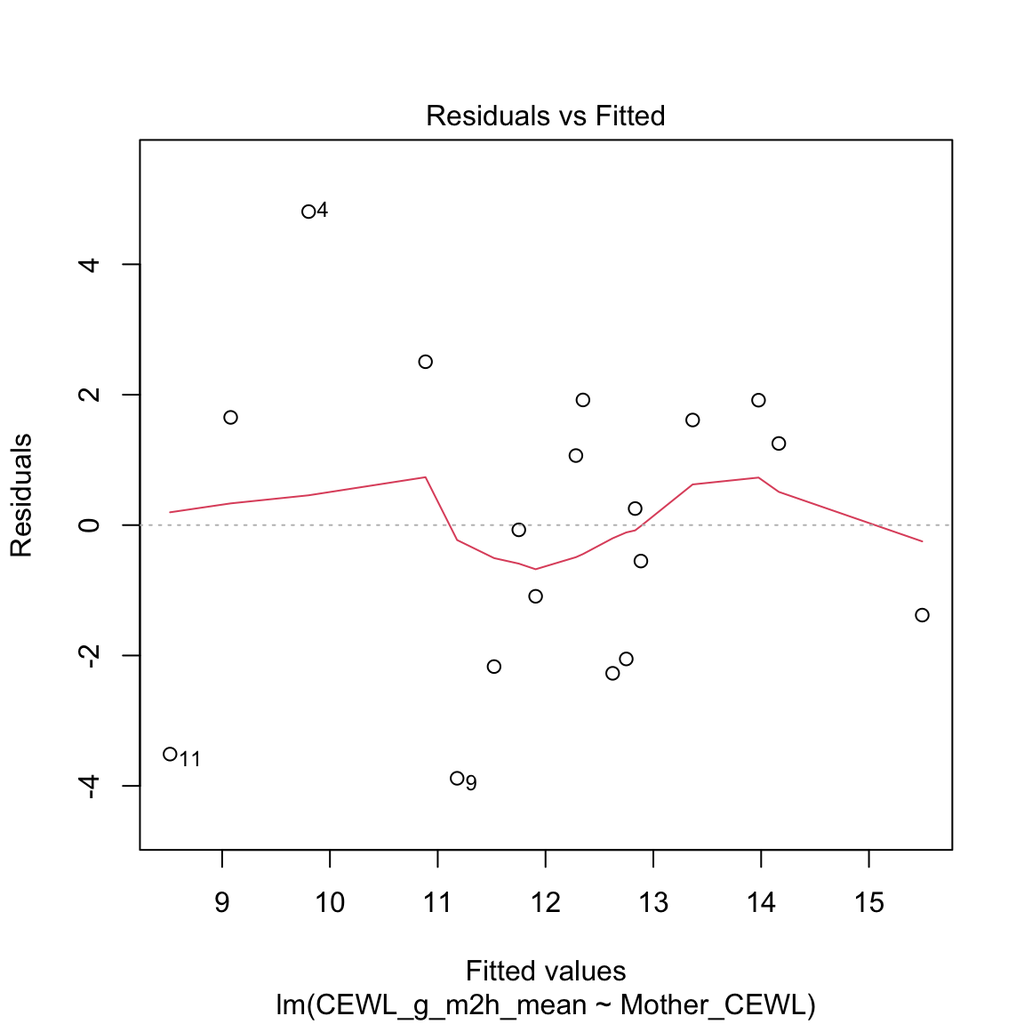

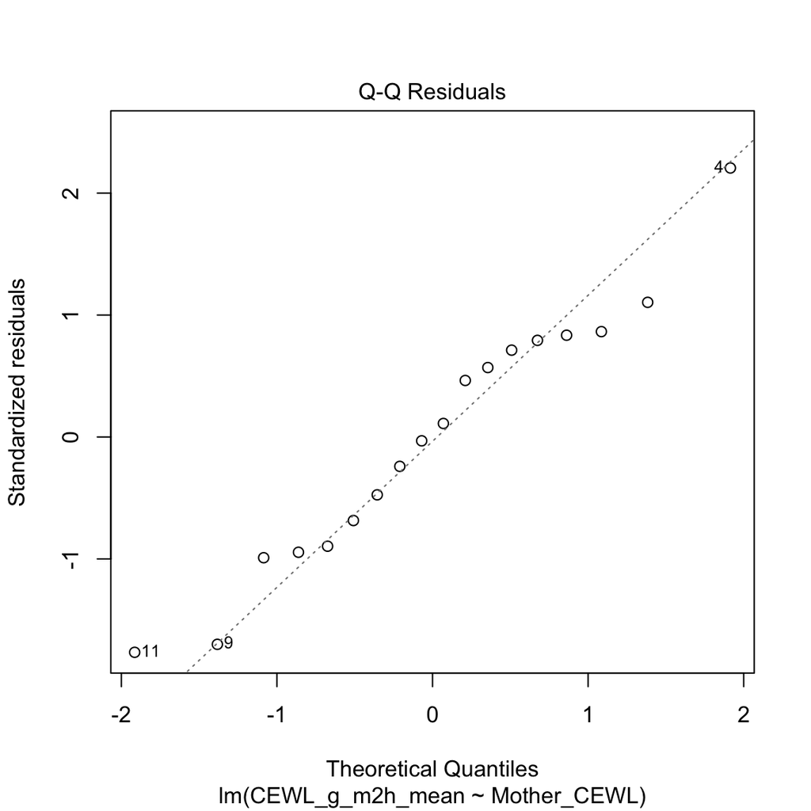

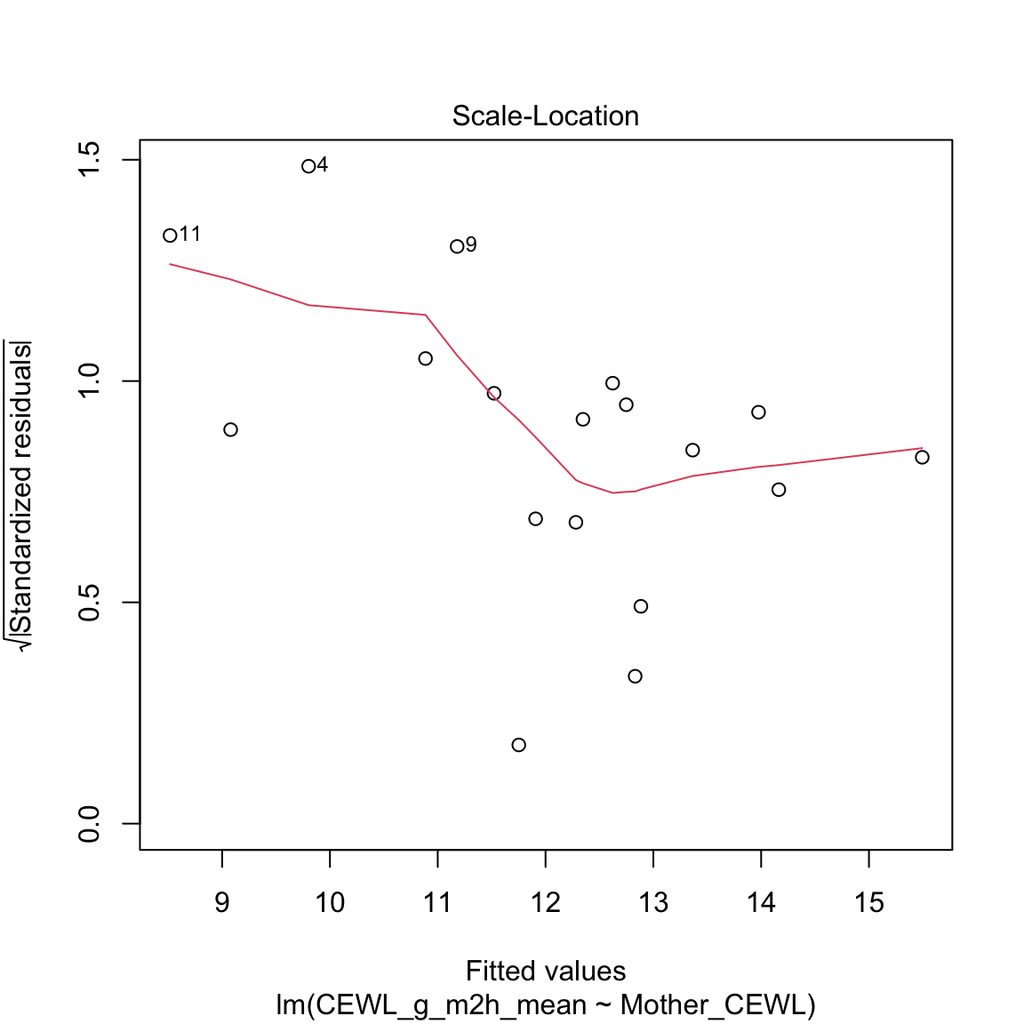

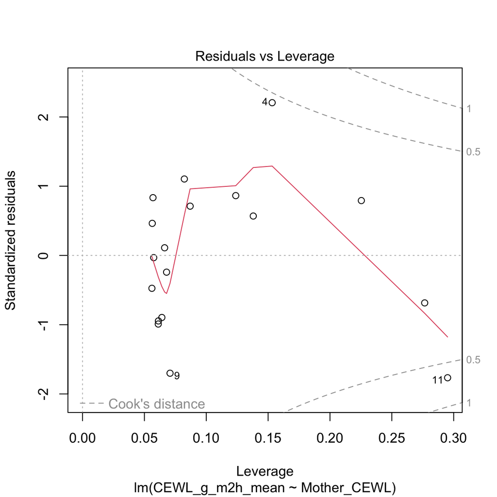

```r
plot(DAB_CEWL_LM_BEST)
```

```r
shapiro.test(residuals(DAB_CEWL_LM_BEST))
```

```
##
##  Shapiro-Wilk normality test
##
## data:  residuals(DAB_CEWL_LM_BEST)
## W = 0.97, p-value = 0.7977
```

# DAB CEWL DIFFS

```r
DAB_CEWL_LMM_1 <- lme4::lmer(data = dab_all,
                      CEWL_g_m2h ~
                      Treatment +
                      Tb_CEWL_c +
                      msmt_temp_C +
                      msmt_RH_percent +
                      VPD_kPa +
                        (1|Mother_ID))

car::vif(DAB_CEWL_LMM_1)
```

```
##       Treatment       Tb_CEWL_c     msmt_temp_C msmt_RH_percent         VPD_kPa
##        1.420919        1.095251      209.510938      237.625552      565.022072
```

```r
drop1(DAB_CEWL_LMM_1)
```

```
## Single term deletions
##
## Model:
## CEWL_g_m2h ~ Treatment + Tb_CEWL_c + msmt_temp_C + msmt_RH_percent +
##     VPD_kPa + (1 | Mother_ID)
##                 npar    AIC
## <none>               419.59
## Treatment          1 417.64
## Tb_CEWL_c          1 419.10
## msmt_temp_C        1 422.03
## msmt_RH_percent    1 423.16
## VPD_kPa            1 422.76
```

```r
car::Anova(DAB_CEWL_LMM_1, test = "F", type = "2")
```

```
## Analysis of Deviance Table (Type II Wald F tests with Kenward-Roger df)
##
## Response: CEWL_g_m2h
##                      F Df Df.res  Pr(>F)
## Treatment       0.0178  1 16.289 0.89546
## Tb_CEWL_c       1.3997  1 73.455 0.24058
## msmt_temp_C     3.4922  1 27.081 0.07251 .
## msmt_RH_percent 4.5409  1 29.227 0.04163 *
## VPD_kPa         4.1596  1 28.388 0.05080 .
## ---
## Signif. codes:  0 '***' 0.001 '**' 0.01 '*' 0.05 '.' 0.1 ' ' 1
```

```r
DAB_CEWL_LMM_1a <- lme4::lmer(data = dab_all,
                      CEWL_g_m2h ~
                      Treatment +
                      Tb_CEWL_c +
                      msmt_temp_C +
                      VPD_kPa +
                        (1|Mother_ID))

car::vif(DAB_CEWL_LMM_1a)
```

```
##   Treatment   Tb_CEWL_c msmt_temp_C     VPD_kPa
##    1.046183    1.035264    2.648575    2.556199
```

```r
drop1(DAB_CEWL_LMM_1a)
```

```
## Single term deletions
##
## Model:
## CEWL_g_m2h ~ Treatment + Tb_CEWL_c + msmt_temp_C + VPD_kPa +
##     (1 | Mother_ID)
##             npar    AIC
## <none>           423.16
## Treatment      1 422.39
## Tb_CEWL_c      1 424.06
## msmt_temp_C    1 426.03
## VPD_kPa        1 422.89
```

```r
car::Anova(DAB_CEWL_LMM_1a, test = "F", type = "2")
```

```
## Analysis of Deviance Table (Type II Wald F tests with Kenward-Roger df)
##
## Response: CEWL_g_m2h
##                  F Df Df.res  Pr(>F)
## Treatment   0.9867  1 13.954 0.33745
## Tb_CEWL_c   2.5322  1 73.801 0.11582
## msmt_temp_C 4.1631  1 22.687 0.05312 .
## VPD_kPa     1.3724  1 26.359 0.25187
## ---
## Signif. codes:  0 '***' 0.001 '**' 0.01 '*' 0.05 '.' 0.1 ' ' 1
```

```r
DAB_CEWL_LMM_2 <- lme4::lmer(data = dab_all,
                      CEWL_g_m2h ~
                      Tb_CEWL_c +
                      msmt_temp_C +
                      VPD_kPa +
                        (1|Mother_ID))

summary(DAB_CEWL_LMM_2)
```

```
## Linear mixed model fit by REML ['lmerMod']
## Formula: CEWL_g_m2h ~ Tb_CEWL_c + msmt_temp_C + VPD_kPa + (1 | Mother_ID)
##    Data: dab_all
##
## REML criterion at convergence: 404
##
## Scaled residuals:
##     Min      1Q  Median      3Q     Max
## -1.3333 -0.6246 -0.1445  0.4638  3.0072
##
## Random effects:
##  Groups    Name        Variance Std.Dev.
##  Mother_ID (Intercept) 5.032    2.243
##  Residual              7.685    2.772
## Number of obs: 80, groups:  Mother_ID, 18
##
## Fixed effects:
##             Estimate Std. Error t value
## (Intercept) -49.6856    20.1844  -2.462
## Tb_CEWL_c     0.4993     0.3101   1.610
## msmt_temp_C   2.3579     1.0543   2.237
## VPD_kPa      -6.7014     5.5996  -1.197
##
## Correlation of Fixed Effects:
##             (Intr) T_CEWL msm__C
## Tb_CEWL_c   -0.254
## msmt_temp_C -0.846 -0.174
## VPD_kPa      0.460  0.100 -0.779
```

```r
drop1(DAB_CEWL_LMM_2)
```

```
## Single term deletions
##
## Model:
## CEWL_g_m2h ~ Tb_CEWL_c + msmt_temp_C + VPD_kPa + (1 | Mother_ID)
##             npar    AIC
## <none>           422.39
## Tb_CEWL_c      1 423.14
## msmt_temp_C    1 425.60
## VPD_kPa        1 421.97
```

```r
car::Anova(DAB_CEWL_LMM_2, test = "F", type = "2")
```

```
## Analysis of Deviance Table (Type II Wald F tests with Kenward-Roger df)
##
## Response: CEWL_g_m2h
##                  F Df Df.res  Pr(>F)
## Tb_CEWL_c   2.4899  1 74.225 0.11883
## msmt_temp_C 4.7137  1 24.394 0.03987 *
## VPD_kPa     1.3354  1 28.377 0.25748
## ---
## Signif. codes:  0 '***' 0.001 '**' 0.01 '*' 0.05 '.' 0.1 ' ' 1
```

```r
DAB_CEWL_LMM_3 <- lme4::lmer(data = dab_all,
                      CEWL_g_m2h ~
                      Tb_CEWL_c +
                      msmt_temp_C +
                        (1|Mother_ID))

summary(DAB_CEWL_LMM_3)
```

```
## Linear mixed model fit by REML ['lmerMod']
## Formula: CEWL_g_m2h ~ Tb_CEWL_c + msmt_temp_C + (1 | Mother_ID)
##    Data: dab_all
##
## REML criterion at convergence: 410.7
##
## Scaled residuals:
##     Min      1Q  Median      3Q     Max
## -1.2992 -0.5731 -0.1714  0.5334  3.0341
##
## Random effects:
##  Groups    Name        Variance Std.Dev.
##  Mother_ID (Intercept) 5.198    2.280
##  Residual              7.690    2.773
## Number of obs: 80, groups:  Mother_ID, 18
##
## Fixed effects:
##             Estimate Std. Error t value
## (Intercept) -38.5837    18.0911  -2.133
## Tb_CEWL_c     0.5343     0.3092   1.728
## msmt_temp_C   1.3773     0.6673   2.064
##
## Correlation of Fixed Effects:
##             (Intr) T_CEWL
## Tb_CEWL_c   -0.337
## msmt_temp_C -0.878 -0.153
```

```r
drop1(DAB_CEWL_LMM_3)
```

```
## Single term deletions
##
## Model:
## CEWL_g_m2h ~ Tb_CEWL_c + msmt_temp_C + (1 | Mother_ID)
##             npar    AIC
## <none>           421.97
## Tb_CEWL_c      1 423.07
## msmt_temp_C    1 424.34
```

```r
car::Anova(DAB_CEWL_LMM_3, test = "F", type = "2")
```

```
## Analysis of Deviance Table (Type II Wald F tests with Kenward-Roger df)
##
## Response: CEWL_g_m2h
##                  F Df Df.res  Pr(>F)
## Tb_CEWL_c   2.8743  1 74.917 0.09416 .
## msmt_temp_C 4.0533  1 24.056 0.05540 .
## ---
## Signif. codes:  0 '***' 0.001 '**' 0.01 '*' 0.05 '.' 0.1 ' ' 1
```

```r
DAB_CEWL_LMM_4 <- lme4::lmer(data = dab_all,
                      CEWL_g_m2h ~
                      msmt_temp_C +
                        (1|Mother_ID))

drop1(DAB_CEWL_LMM_4)
```

```
## Single term deletions
##
## Model:
## CEWL_g_m2h ~ msmt_temp_C + (1 | Mother_ID)
##             npar    AIC
## <none>           423.07
## msmt_temp_C    1 426.30
```

```r
car::Anova(DAB_CEWL_LMM_4, test = "F", type = "2")
```

```
## Analysis of Deviance Table (Type II Wald F tests with Kenward-Roger df)
##
## Response: CEWL_g_m2h
##                  F Df Df.res  Pr(>F)
## msmt_temp_C 4.9935  1 23.872 0.03507 *
## ---
## Signif. codes:  0 '***' 0.001 '**' 0.01 '*' 0.05 '.' 0.1 ' ' 1
```

```r
DAB_CEWL_LMM_NULL <- lme4::lmer(data = dab_all,
                      CEWL_g_m2h ~ 1 + (1|Mother_ID))
```

## Model Selection

```r
cewl_models_all <- list(DAB_CEWL_LMM_1a, DAB_CEWL_LMM_2,
                        DAB_CEWL_LMM_3, DAB_CEWL_LMM_4,
                        DAB_CEWL_LMM_NULL)

#specify model names
cewl_mod_names_all <- c('model1',
                    'model2',
                    'model3',
                    'model4',
                    'modelnull')

#calculate AIC of each model
cewl_AICc_all <- data.frame(aictab(cand.set = cewl_models_all,
                                 modnames = cewl_mod_names_all))
cewl_AICc_all
```

```
##    Modnames K     AICc Delta_AICc    ModelLik     AICcWt    Res.LL    Cum.Wt
## 1    model1 7 416.2686   0.000000 1.000000000 0.55821441 -200.3565 0.5582144
## 2    model2 6 417.1534   0.884841 0.642479428 0.35864128 -202.0014 0.9168557
## 3    model3 5 421.5240   5.255453 0.072242519 0.04032682 -205.3566 0.9571825
## 4    model4 4 421.6758   5.407253 0.066962250 0.03737929 -206.5712 0.9945618
## 5 modelnull 3 425.5311   9.262590 0.009742134 0.00543820 -209.6077 1.0000000
```

Models 1 and 2 are the best… which includes all variables Treatment + Tb_CEWL_c + msmt_temp_C + VPD_kPa

## Final Model + emmeans

```r
DAB_CEWL_LMM_BEST1 <- lmerTest::lmer(data = dab_all,
                      CEWL_g_m2h ~
                      Treatment +
                      Tb_CEWL_c +
                      msmt_temp_C +
                      VPD_kPa +
                        (1|Mother_ID))

summary(DAB_CEWL_LMM_BEST1)
```

```
## Linear mixed model fit by REML. t-tests use Satterthwaite's method [
## lmerModLmerTest]
## Formula: CEWL_g_m2h ~ Treatment + Tb_CEWL_c + msmt_temp_C + VPD_kPa +
##     (1 | Mother_ID)
##    Data: dab_all
##
## REML criterion at convergence: 400.7
##
## Scaled residuals:
##     Min      1Q  Median      3Q     Max
## -1.3466 -0.5846 -0.1591  0.4431  3.0612
##
## Random effects:
##  Groups    Name        Variance Std.Dev.
##  Mother_ID (Intercept) 4.970    2.229
##  Residual              7.703    2.775
## Number of obs: 80, groups:  Mother_ID, 18
##
## Fixed effects:
##             Estimate Std. Error       df t value Pr(>|t|)
## (Intercept) -45.6365    20.5270  23.5783  -2.223   0.0361 *
## TreatmentW   -1.2539     1.2602  15.1961  -0.995   0.3353
## Tb_CEWL_c     0.5044     0.3103  73.9194   1.626   0.1083
## msmt_temp_C   2.2294     1.0588  24.3950   2.106   0.0457 *
## VPD_kPa      -6.7888     5.5850  28.1944  -1.216   0.2342
## ---
## Signif. codes:  0 '***' 0.001 '**' 0.01 '*' 0.05 '.' 0.1 ' ' 1
##
## Correlation of Fixed Effects:
##             (Intr) TrtmnW T_CEWL msm__C
## TreatmentW  -0.198
## Tb_CEWL_c   -0.247 -0.014
## msmt_temp_C -0.847  0.121 -0.175
## VPD_kPa      0.447  0.015  0.100 -0.772
```

```r
car::Anova(DAB_CEWL_LMM_BEST1, test = "F", type = "2")
```

```
## Analysis of Deviance Table (Type II Wald F tests with Kenward-Roger df)
##
## Response: CEWL_g_m2h
##                  F Df Df.res  Pr(>F)
## Treatment   0.9867  1 13.954 0.33745
## Tb_CEWL_c   2.5322  1 73.801 0.11582
## msmt_temp_C 4.1631  1 22.687 0.05312 .
## VPD_kPa     1.3724  1 26.359 0.25187
## ---
## Signif. codes:  0 '***' 0.001 '**' 0.01 '*' 0.05 '.' 0.1 ' ' 1
```

```r
emmeans(DAB_CEWL_LMM_BEST1, pairwise ~ Treatment)
```

```
## $emmeans
##  Treatment emmean    SE   df lower.CL upper.CL
##  C           12.7 0.941 14.1     10.7     14.7
##  W           11.5 0.822 13.6      9.7     13.2
##
## Degrees-of-freedom method: kenward-roger
## Confidence level used: 0.95
##
## $contrasts
##  contrast estimate   SE   df t.ratio p.value
##  C - W        1.25 1.26 13.9   0.993  0.3375
##
## Degrees-of-freedom method: kenward-roger
```

```r
DAB_CEWL_emmeans <- emmeans(DAB_CEWL_LMM_BEST1, "Treatment")
DAB_CEWL_emmeans_CI <- tidy(confint(DAB_CEWL_emmeans))
```

```r
DAB_CEWL_LMM_BEST2 <- lmerTest::lmer(data = dab_all,
                      CEWL_g_m2h ~
                      Tb_CEWL_c +
                      msmt_temp_C +
                      VPD_kPa +
                        (1|Mother_ID))

summary(DAB_CEWL_LMM_BEST2)
```

```
## Linear mixed model fit by REML. t-tests use Satterthwaite's method [
## lmerModLmerTest]
## Formula: CEWL_g_m2h ~ Tb_CEWL_c + msmt_temp_C + VPD_kPa + (1 | Mother_ID)
##    Data: dab_all
##
## REML criterion at convergence: 404
##
## Scaled residuals:
##     Min      1Q  Median      3Q     Max
## -1.3333 -0.6246 -0.1445  0.4638  3.0072
##
## Random effects:
##  Groups    Name        Variance Std.Dev.
##  Mother_ID (Intercept) 5.032    2.243
##  Residual              7.685    2.772
## Number of obs: 80, groups:  Mother_ID, 18
##
## Fixed effects:
##             Estimate Std. Error       df t value Pr(>|t|)
## (Intercept) -49.6856    20.1844  25.4782  -2.462   0.0209 *
## Tb_CEWL_c     0.4993     0.3101  74.4076   1.610   0.1116
## msmt_temp_C   2.3579     1.0543  26.2721   2.237   0.0340 *
## VPD_kPa      -6.7014     5.5996  30.3811  -1.197   0.2407
## ---
## Signif. codes:  0 '***' 0.001 '**' 0.01 '*' 0.05 '.' 0.1 ' ' 1
##
## Correlation of Fixed Effects:
##             (Intr) T_CEWL msm__C
## Tb_CEWL_c   -0.254
## msmt_temp_C -0.846 -0.174
## VPD_kPa      0.460  0.100 -0.779
```

```r
car::Anova(DAB_CEWL_LMM_BEST2, test = "F", type = "2")
```

```
## Analysis of Deviance Table (Type II Wald F tests with Kenward-Roger df)
##
## Response: CEWL_g_m2h
##                  F Df Df.res  Pr(>F)
## Tb_CEWL_c   2.4899  1 74.225 0.11883
## msmt_temp_C 4.7137  1 24.394 0.03987 *
## VPD_kPa     1.3354  1 28.377 0.25748
## ---
## Signif. codes:  0 '***' 0.001 '**' 0.01 '*' 0.05 '.' 0.1 ' ' 1
```

## Model Assumptions

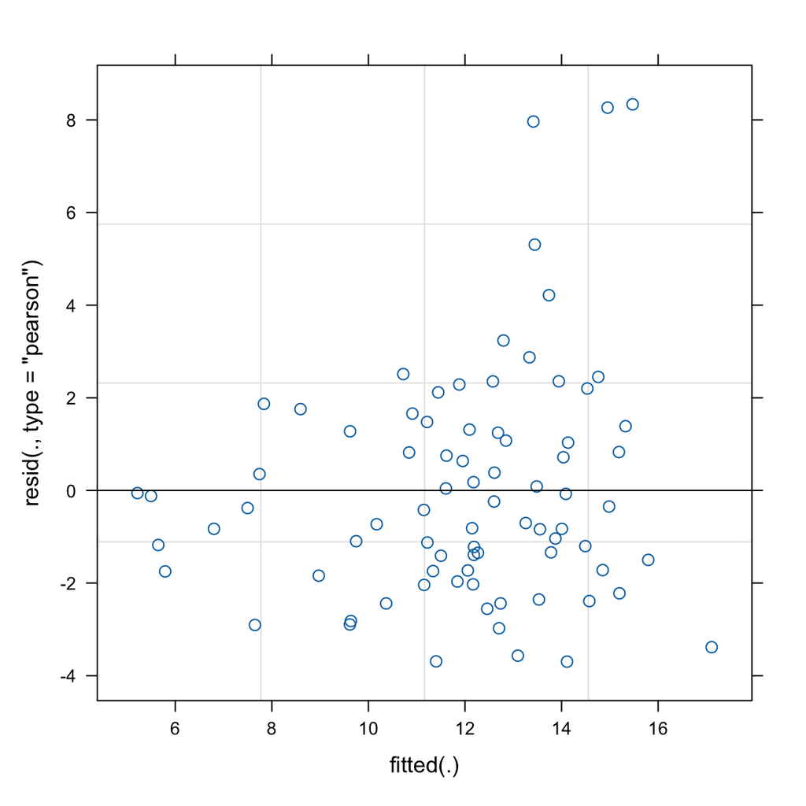

```r
plot(DAB_CEWL_LMM_BEST2)
```

```r
shapiro.test(residuals(DAB_CEWL_LMM_BEST2))
```

```
##
##  Shapiro-Wilk normality test
##
## data:  residuals(DAB_CEWL_LMM_BEST2)
## W = 0.90263, p-value = 1.576e-05
```

looks fine, but not great

# DAB osml clutch ~ mother

```r
DAB_osml_LM_1 <- lm(data = dab_clutch_mom,
                      Plasma_Osmol_Rep_mean_mean ~
                      Treatment *
                      (Mother_osml + Mother_Days_in_Treatment) +
                      Mass_g_mean)

car::vif(DAB_osml_LM_1, type = "predictor")
```

```
## GVIFs computed for predictors
```

```
##                                 GVIF Df GVIF^(1/(2*Df))
## Treatment                   1.316106  5        1.027848
## Mother_osml                 9.171779  3        1.446801
## Mother_Days_in_Treatment 1004.349474  3        3.164566
## Mass_g_mean                 1.316106  1        1.147217
##                                                 Interacts With
## Treatment                Mother_osml, Mother_Days_in_Treatment
## Mother_osml                                          Treatment
## Mother_Days_in_Treatment                             Treatment
## Mass_g_mean                                               --
##                                                          Other Predictors
## Treatment                                                     Mass_g_mean
## Mother_osml                         Mother_Days_in_Treatment, Mass_g_mean
## Mother_Days_in_Treatment                         Mother_osml, Mass_g_mean
## Mass_g_mean              Treatment, Mother_osml, Mother_Days_in_Treatment
```

```r
drop1(DAB_osml_LM_1)
```

```
## Single term deletions
##
## Model:
## Plasma_Osmol_Rep_mean_mean ~ Treatment * (Mother_osml + Mother_Days_in_Treatment) +
##     Mass_g_mean
##                                    Df Sum of Sq    RSS    AIC
## <none>                                          1168.5 89.116
## Mass_g_mean                         1     1.917 1170.4 87.145
## Treatment:Mother_osml               1     6.144 1174.6 87.210
## Treatment:Mother_Days_in_Treatment  1   154.172 1322.7 89.347
```

```r
car::Anova(DAB_osml_LM_1, type = "2")
```

```
## Anova Table (Type II tests)
##
## Response: Plasma_Osmol_Rep_mean_mean
##                                     Sum Sq Df F value  Pr(>F)
## Treatment                           455.34  1  4.2865 0.06273 .
## Mother_osml                          43.60  1  0.4105 0.53485
## Mother_Days_in_Treatment            115.96  1  1.0916 0.31852
## Mass_g_mean                           1.92  1  0.0181 0.89555
## Treatment:Mother_osml                 6.14  1  0.0578 0.81437
## Treatment:Mother_Days_in_Treatment  154.17  1  1.4514 0.25359
## Residuals                          1168.49 11
## ---
## Signif. codes:  0 '***' 0.001 '**' 0.01 '*' 0.05 '.' 0.1 ' ' 1
```

```r
DAB_osml_LM_2a <- lm(data = dab_clutch_mom,
                      Plasma_Osmol_Rep_mean_mean ~
                      Treatment * Mother_Days_in_Treatment +
                      Mother_osml +
                      Mass_g_mean)

drop1(DAB_osml_LM_2a)
```

```
## Single term deletions
##
## Model:
## Plasma_Osmol_Rep_mean_mean ~ Treatment * Mother_Days_in_Treatment +
##     Mother_osml + Mass_g_mean
##                                    Df Sum of Sq    RSS    AIC
## <none>                                          1174.6 87.210
## Mother_osml                         1    43.603 1218.2 85.866
## Mass_g_mean                         1     5.030 1179.7 85.287
## Treatment:Mother_Days_in_Treatment  1   152.067 1326.7 87.401
```

```r
car::Anova(DAB_osml_LM_2a, type = "2")
```

```
## Anova Table (Type II tests)
##
## Response: Plasma_Osmol_Rep_mean_mean
##                                     Sum Sq Df F value  Pr(>F)
## Treatment                           455.34  1  4.6517 0.05201 .
## Mother_Days_in_Treatment            124.13  1  1.2681 0.28215
## Mother_osml                          43.60  1  0.4454 0.51714
## Mass_g_mean                           5.03  1  0.0514 0.82449
## Treatment:Mother_Days_in_Treatment  152.07  1  1.5535 0.23640
## Residuals                          1174.63 12
## ---
## Signif. codes:  0 '***' 0.001 '**' 0.01 '*' 0.05 '.' 0.1 ' ' 1
```

```r
DAB_osml_LM_2b <- lm(data = dab_clutch_mom,
                      Plasma_Osmol_Rep_mean_mean ~
                      Treatment *
                      (Mother_osml + Mother_Days_in_Treatment))
drop1(DAB_osml_LM_2b)
```

```
## Single term deletions
##
## Model:
## Plasma_Osmol_Rep_mean_mean ~ Treatment * (Mother_osml + Mother_Days_in_Treatment)
##                                    Df Sum of Sq    RSS    AIC
## <none>                                          1170.4 87.145
## Treatment:Mother_osml               1     9.256 1179.7 85.287
## Treatment:Mother_Days_in_Treatment  1   152.289 1322.7 87.347
```

```r
car::Anova(DAB_osml_LM_2b, type = "2")
```

```
## Anova Table (Type II tests)
##
## Response: Plasma_Osmol_Rep_mean_mean
##                                     Sum Sq Df F value  Pr(>F)
## Treatment                           507.00  1  5.1982 0.04168 *
## Mother_osml                          58.46  1  0.5994 0.45381
## Mother_Days_in_Treatment            118.37  1  1.2136 0.29222
## Treatment:Mother_osml                 9.26  1  0.0949 0.76332
## Treatment:Mother_Days_in_Treatment  152.29  1  1.5614 0.23528
## Residuals                          1170.41 12
## ---
## Signif. codes:  0 '***' 0.001 '**' 0.01 '*' 0.05 '.' 0.1 ' ' 1
```

```r
DAB_osml_LM_3 <- lm(data = dab_clutch_mom,
                      Plasma_Osmol_Rep_mean_mean ~
                      Treatment * Mother_Days_in_Treatment +
                      Mother_osml)

drop1(DAB_osml_LM_3)
```

```
## Single term deletions
##
## Model:
## Plasma_Osmol_Rep_mean_mean ~ Treatment * Mother_Days_in_Treatment +
##     Mother_osml
##                                    Df Sum of Sq    RSS    AIC
## <none>                                          1179.7 85.287
## Mother_osml                         1    58.457 1238.1 84.158
## Treatment:Mother_Days_in_Treatment  1   148.060 1327.7 85.415
```

```r
car::Anova(DAB_osml_LM_3, type = "2")
```

```
## Anova Table (Type II tests)
##
## Response: Plasma_Osmol_Rep_mean_mean
##                                     Sum Sq Df F value  Pr(>F)
## Treatment                           507.00  1  5.5872 0.03434 *
## Mother_Days_in_Treatment            133.48  1  1.4710 0.24677
## Mother_osml                          58.46  1  0.6442 0.43662
## Treatment:Mother_Days_in_Treatment  148.06  1  1.6316 0.22382
## Residuals                          1179.66 13
## ---
## Signif. codes:  0 '***' 0.001 '**' 0.01 '*' 0.05 '.' 0.1 ' ' 1
```

```r
DAB_osml_LM_4 <- lm(data = dab_clutch_mom,
                      Plasma_Osmol_Rep_mean_mean ~
                      Treatment * Mother_Days_in_Treatment)

drop1(DAB_osml_LM_4)
```

```
## Single term deletions
##
## Model:
## Plasma_Osmol_Rep_mean_mean ~ Treatment * Mother_Days_in_Treatment
##                                    Df Sum of Sq    RSS    AIC
## <none>                                          1238.1 84.158
## Treatment:Mother_Days_in_Treatment  1    225.53 1463.7 85.170
```

```r
car::Anova(DAB_osml_LM_4, type = "2")
```

```
## Anova Table (Type II tests)
##
## Response: Plasma_Osmol_Rep_mean_mean
##                                     Sum Sq Df F value   Pr(>F)
## Treatment                           828.57  1  9.3690 0.008465 **
## Mother_Days_in_Treatment            390.16  1  4.4117 0.054293 .
## Treatment:Mother_Days_in_Treatment  225.53  1  2.5502 0.132602
## Residuals                          1238.12 14
## ---
## Signif. codes:  0 '***' 0.001 '**' 0.01 '*' 0.05 '.' 0.1 ' ' 1
```

```r
DAB_osml_LM_5 <- lm(data = dab_clutch_mom,
                      Plasma_Osmol_Rep_mean_mean ~
                      Treatment + Mother_Days_in_Treatment)

drop1(DAB_osml_LM_5)
```

```
## Single term deletions
##
## Model:
## Plasma_Osmol_Rep_mean_mean ~ Treatment + Mother_Days_in_Treatment
##                          Df Sum of Sq    RSS    AIC
## <none>                                1463.7 85.170
## Treatment                 1    828.57 2292.2 91.244
## Mother_Days_in_Treatment  1    390.16 1853.8 87.423
```

```r
car::Anova(DAB_osml_LM_5, type = "2")
```

```
## Anova Table (Type II tests)
##
## Response: Plasma_Osmol_Rep_mean_mean
##                           Sum Sq Df F value  Pr(>F)
## Treatment                 828.57  1  8.4914 0.01069 *
## Mother_Days_in_Treatment  390.16  1  3.9985 0.06399 .
## Residuals                1463.65 15
## ---
## Signif. codes:  0 '***' 0.001 '**' 0.01 '*' 0.05 '.' 0.1 ' ' 1
```

```r
DAB_osml_LM_6 <- lm(data = dab_clutch_mom,
                      Plasma_Osmol_Rep_mean_mean ~
                      Treatment)

car::Anova(DAB_osml_LM_6, type = "2")
```

```
## Anova Table (Type II tests)
##
## Response: Plasma_Osmol_Rep_mean_mean
##            Sum Sq Df F value  Pr(>F)
## Treatment  811.93  1  7.0077 0.01757 *
## Residuals 1853.80 16
## ---
## Signif. codes:  0 '***' 0.001 '**' 0.01 '*' 0.05 '.' 0.1 ' ' 1
```

```r
DAB_osml_LM_null <- lm(data = dab_clutch_mom, Plasma_Osmol_Rep_mean_mean ~ 1)
```

## Model Selection

```r
clutch_osmol_models_all <- list(DAB_osml_LM_1, DAB_osml_LM_2a, DAB_osml_LM_3, DAB_osml_LM_4, DAB_osml_LM_5, DAB_osml_LM_6, DAB_osml_LM_null)

#specify model names
clutch_osmol_mod_names_all <- c('model1',
                    'model2',
                    'model3',
                    'model4',
                    'model5',
                    'model6',
                    'modelnull')

#calculate AIC of each model
clutch_osmol_AICc_all <- data.frame(aictab(cand.set = clutch_osmol_models_all,
                                 modnames = clutch_osmol_mod_names_all))
clutch_osmol_AICc_all
```

```
##    Modnames K     AICc Delta_AICc    ModelLik       AICcWt        LL    Cum.Wt
## 5    model5 4 141.3284  0.0000000 1.000000000 4.028689e-01 -65.12573 0.4028689
## 6    model6 3 142.2193  0.8908989 0.640536320 2.580522e-01 -67.25250 0.6609211
## 4    model4 5 142.2394  0.9109883 0.634134522 2.554731e-01 -63.61969 0.9163942
## 7 modelnull 2 145.8433  4.5149020 0.104616812 4.214686e-02 -70.52165 0.9585410
## 3    model3 6 146.0052  4.6767763 0.096483027 3.887001e-02 -63.18440 0.9974111
## 2    model2 7 151.4919 10.1635002 0.006209033 2.501427e-03 -63.14595 0.9999125
## 1    model1 8 158.1975 16.8691074 0.000217230 8.751523e-05 -63.09875 1.0000000
```

The best top/equivalent models are 5 (tmt + mother days in tmt), 6 (tmt only), and 4 (tmt * mother days in tmt).

## Final Model

```r
DAB_osml_LM_BEST <- lm(data = dab_clutch_mom,
                       Plasma_Osmol_Rep_mean_mean ~
                          Treatment)

car::Anova(DAB_osml_LM_BEST, type = "2")
```

```
## Anova Table (Type II tests)
##
## Response: Plasma_Osmol_Rep_mean_mean
##            Sum Sq Df F value  Pr(>F)
## Treatment  811.93  1  7.0077 0.01757 *
## Residuals 1853.80 16
## ---
## Signif. codes:  0 '***' 0.001 '**' 0.01 '*' 0.05 '.' 0.1 ' ' 1
```

```r
summary(DAB_osml_LM_BEST)
```

```
##
## Call:
## lm(formula = Plasma_Osmol_Rep_mean_mean ~ Treatment, data = dab_clutch_mom)
##
## Residuals:
##      Min       1Q   Median       3Q      Max
## -20.3615  -8.7975   0.3219   7.8067  20.5719
##
## Coefficients:
##             Estimate Std. Error t value Pr(>|t|)
## (Intercept)  304.095      3.806  79.906   <2e-16 ***
## TreatmentW   -13.516      5.106  -2.647   0.0176 *
## ---
## Signif. codes:  0 '***' 0.001 '**' 0.01 '*' 0.05 '.' 0.1 ' ' 1
##
## Residual standard error: 10.76 on 16 degrees of freedom
## Multiple R-squared:  0.3046, Adjusted R-squared:  0.2611
## F-statistic: 7.008 on 1 and 16 DF,  p-value: 0.01757
```

```r
DAB_osml_LM_BEST_add <- lm(data = dab_clutch_mom,
                       Plasma_Osmol_Rep_mean_mean ~
                          Treatment + Mother_Days_in_Treatment)

car::Anova(DAB_osml_LM_BEST_add, type = "2")
```

```
## Anova Table (Type II tests)
##
## Response: Plasma_Osmol_Rep_mean_mean
##                           Sum Sq Df F value  Pr(>F)
## Treatment                 828.57  1  8.4914 0.01069 *
## Mother_Days_in_Treatment  390.16  1  3.9985 0.06399 .
## Residuals                1463.65 15
## ---
## Signif. codes:  0 '***' 0.001 '**' 0.01 '*' 0.05 '.' 0.1 ' ' 1
```

```r
summary(DAB_osml_LM_BEST_add)
```

```
##
## Call:
## lm(formula = Plasma_Osmol_Rep_mean_mean ~ Treatment + Mother_Days_in_Treatment,
##     data = dab_clutch_mom)
##
## Residuals:
##      Min       1Q   Median       3Q      Max
## -15.0217  -7.4365   0.6639   5.2247  15.3004
##
## Coefficients:
##                          Estimate Std. Error t value Pr(>|t|)
## (Intercept)              295.9690     5.3582  55.236   <2e-16 ***
## TreatmentW               -13.6553     4.6861  -2.914   0.0107 *
## Mother_Days_in_Treatment   0.9287     0.4644   2.000   0.0640 .
## ---
## Signif. codes:  0 '***' 0.001 '**' 0.01 '*' 0.05 '.' 0.1 ' ' 1
##
## Residual standard error: 9.878 on 15 degrees of freedom
## Multiple R-squared:  0.4509, Adjusted R-squared:  0.3777
## F-statistic:  6.16 on 2 and 15 DF,  p-value: 0.01115
```

```r
DAB_osml_LM_BEST_int <- lm(data = dab_clutch_mom,
                       Plasma_Osmol_Rep_mean_mean ~
                          Treatment * Mother_Days_in_Treatment)

car::Anova(DAB_osml_LM_BEST_int, type = "2")
```

```
## Anova Table (Type II tests)
##
## Response: Plasma_Osmol_Rep_mean_mean
##                                     Sum Sq Df F value   Pr(>F)
## Treatment                           828.57  1  9.3690 0.008465 **
## Mother_Days_in_Treatment            390.16  1  4.4117 0.054293 .
## Treatment:Mother_Days_in_Treatment  225.53  1  2.5502 0.132602
## Residuals                          1238.12 14
## ---
## Signif. codes:  0 '***' 0.001 '**' 0.01 '*' 0.05 '.' 0.1 ' ' 1
```

```r
summary(DAB_osml_LM_BEST_int)
```

```
##
## Call:
## lm(formula = Plasma_Osmol_Rep_mean_mean ~ Treatment * Mother_Days_in_Treatment,
##     data = dab_clutch_mom)
##
## Residuals:
##     Min      1Q  Median      3Q     Max
## -11.708  -8.931  -0.686   7.514  11.664
##
## Coefficients:
##                                     Estimate Std. Error t value Pr(>|t|)
## (Intercept)                         290.9261     5.9995  48.492   <2e-16 ***
## TreatmentW                           -0.9141     9.1412  -0.100   0.9218
## Mother_Days_in_Treatment              1.5050     0.5707   2.637   0.0195 *
## TreatmentW:Mother_Days_in_Treatment  -1.4413     0.9026  -1.597   0.1326
## ---
## Signif. codes:  0 '***' 0.001 '**' 0.01 '*' 0.05 '.' 0.1 ' ' 1
##
## Residual standard error: 9.404 on 14 degrees of freedom
## Multiple R-squared:  0.5355, Adjusted R-squared:  0.436
## F-statistic: 5.381 on 3 and 14 DF,  p-value: 0.01128
```

## Model Assumptions

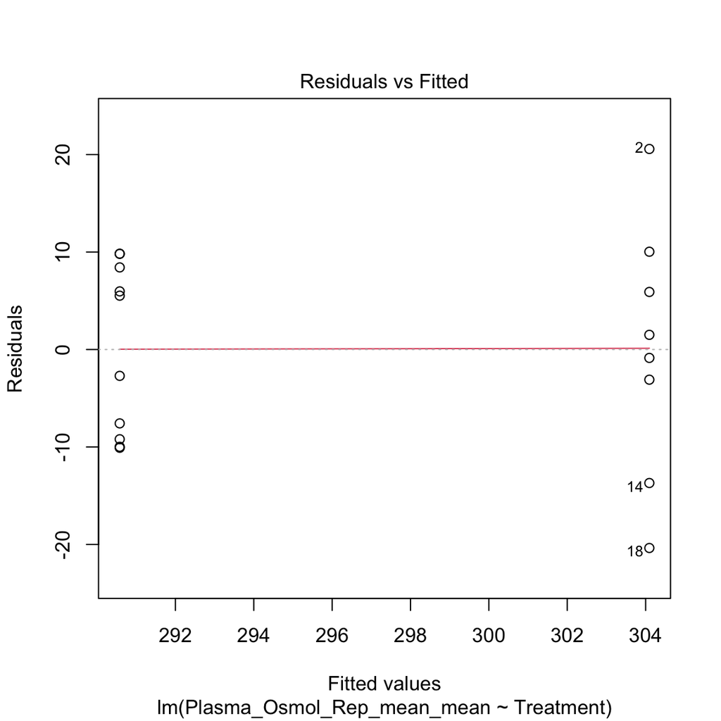

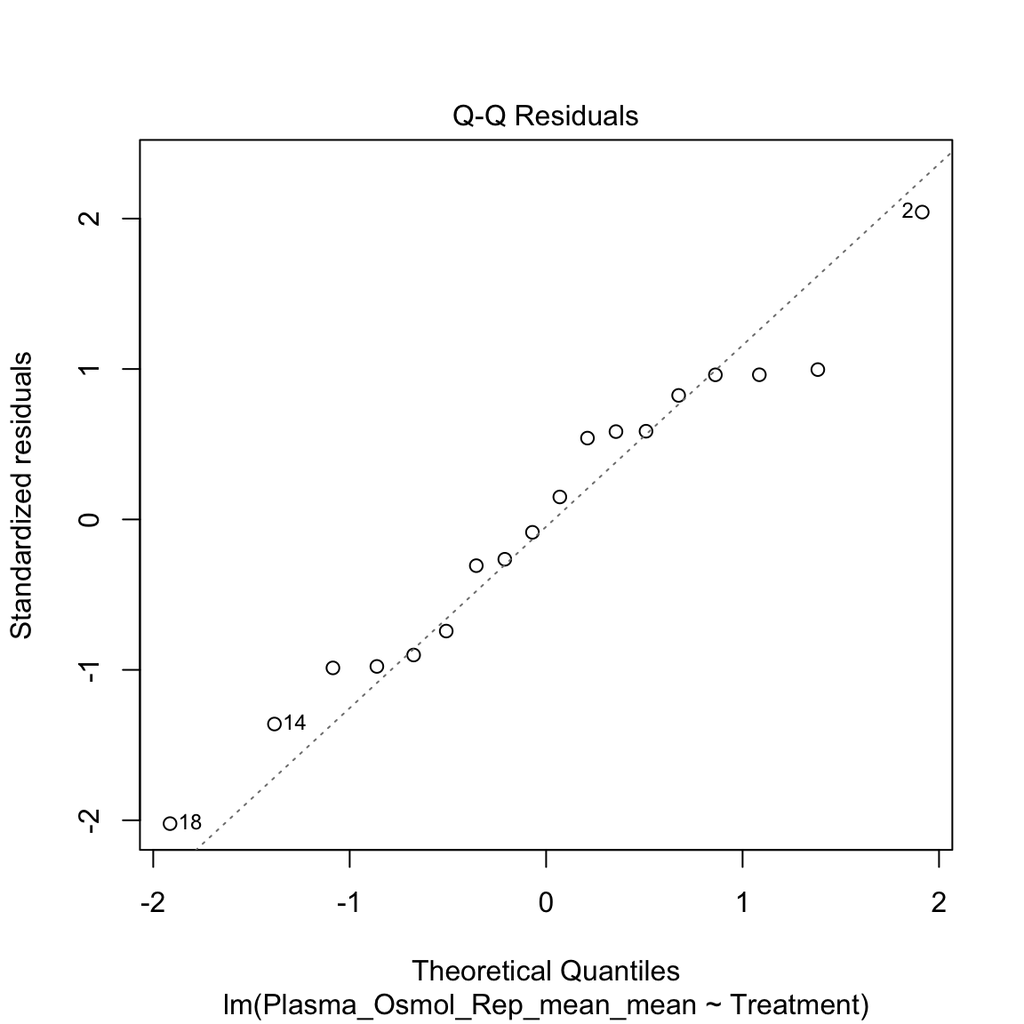

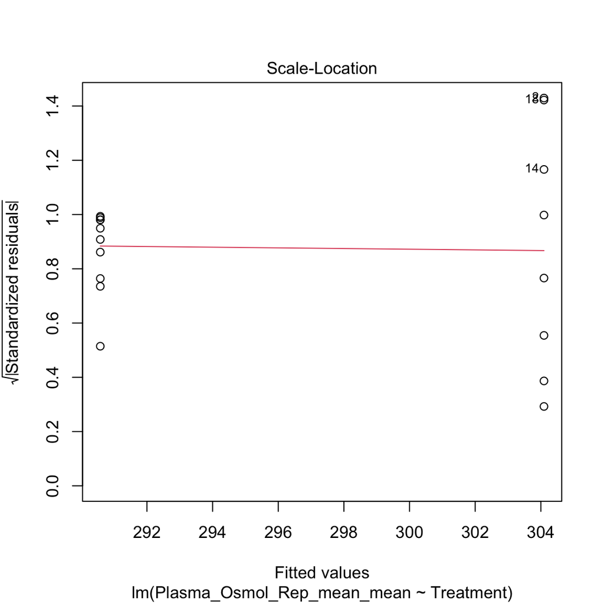

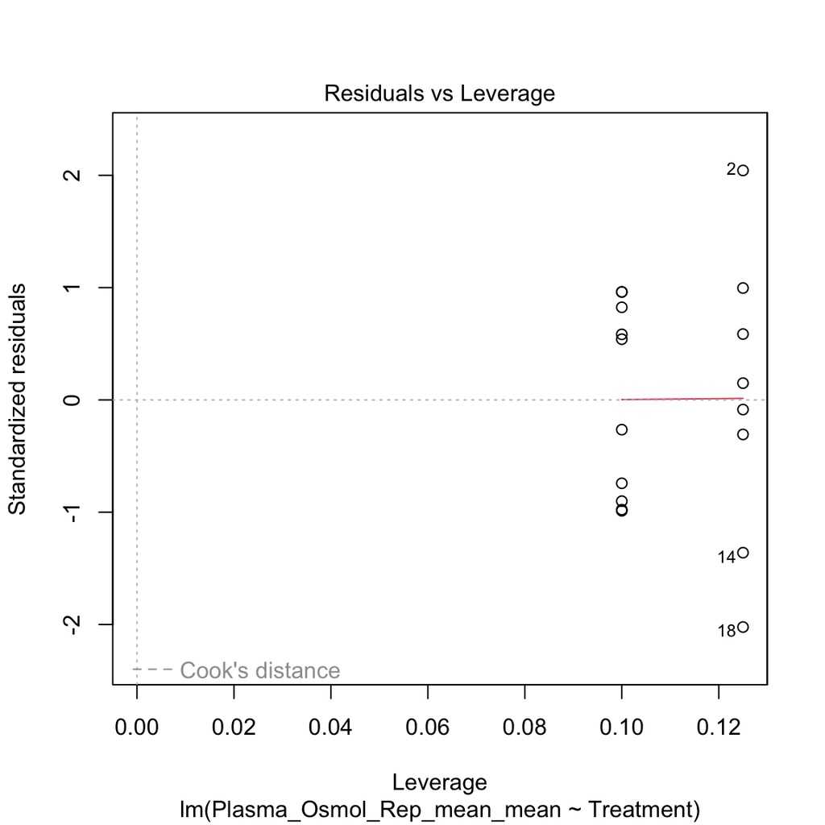

```r
plot(DAB_osml_LM_BEST)
```

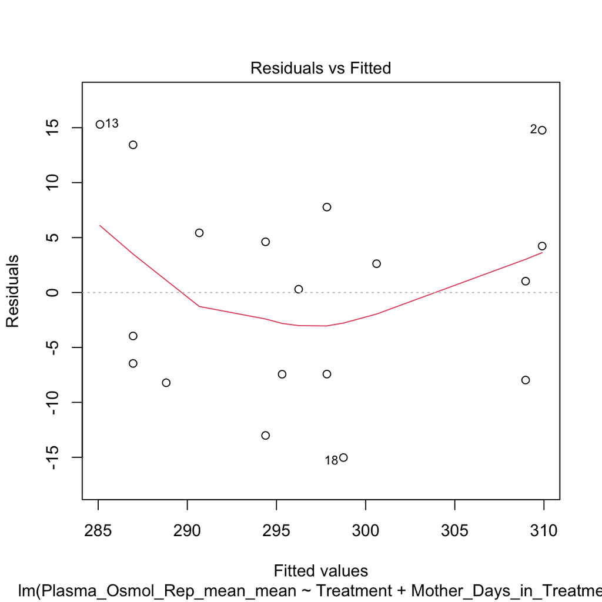

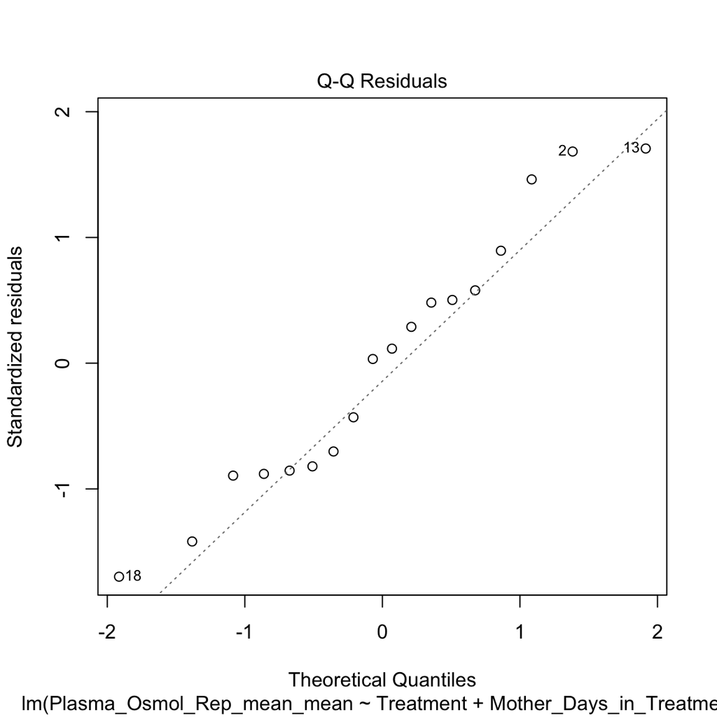

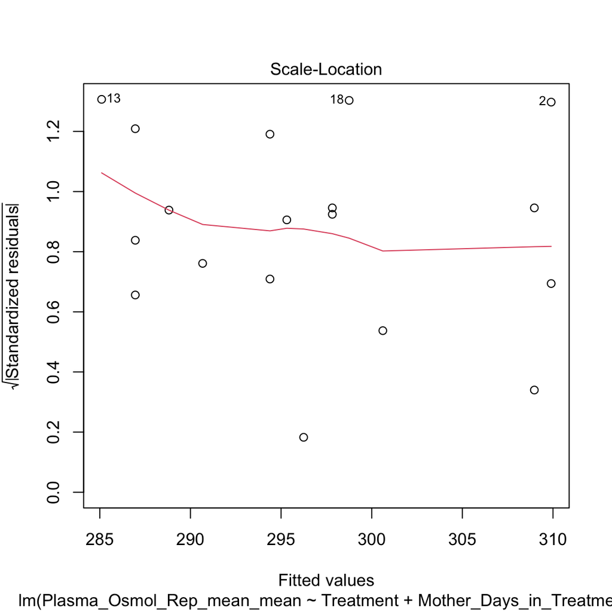

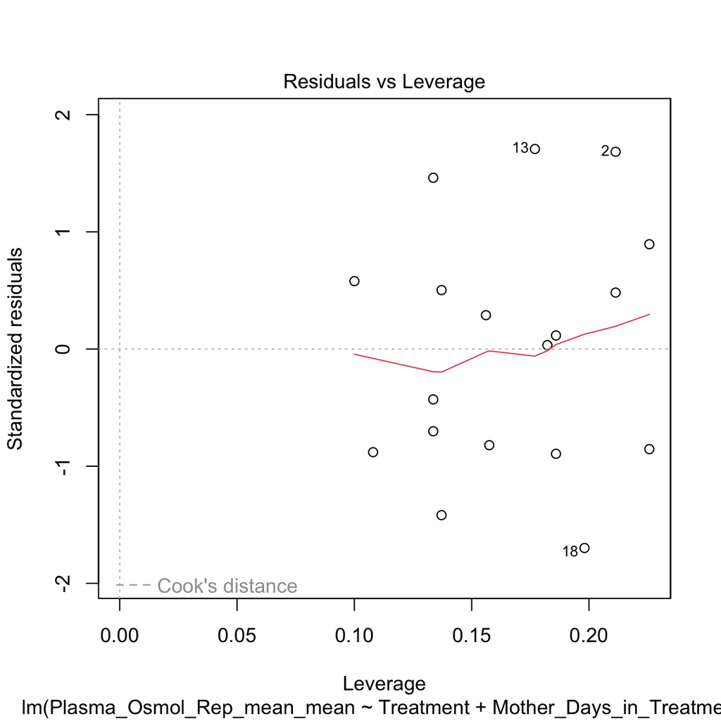

```r
plot(DAB_osml_LM_BEST_add)
```

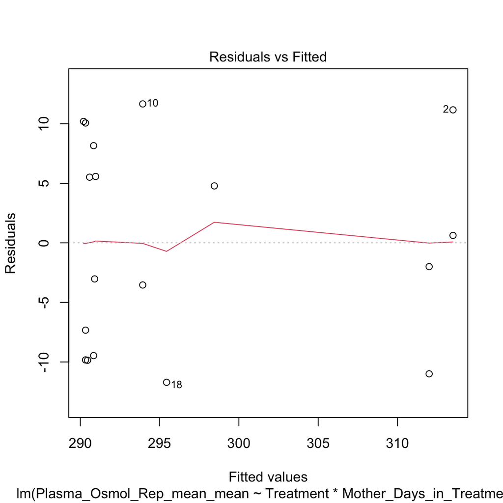

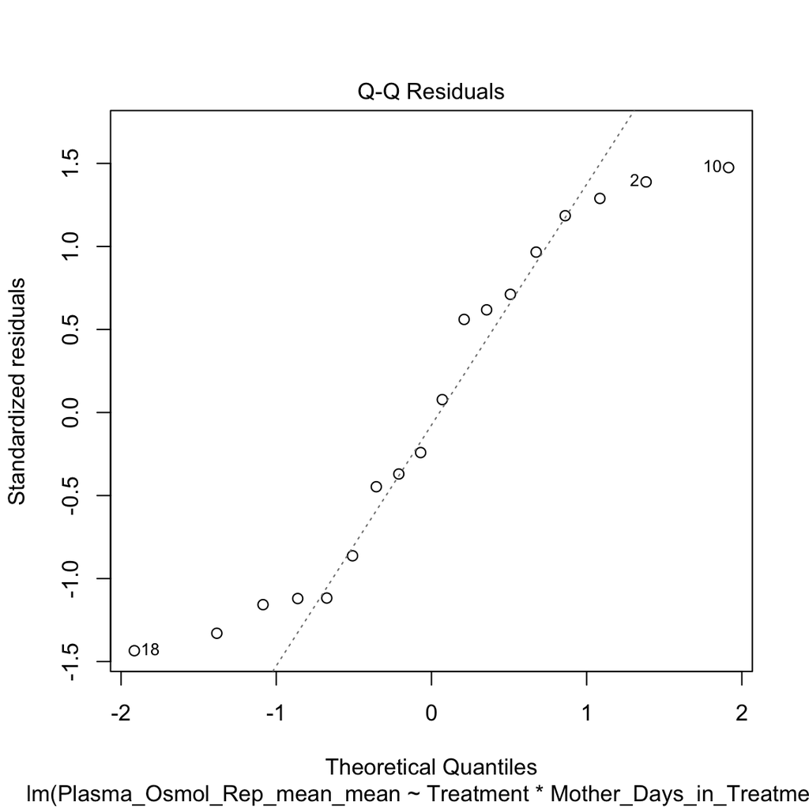

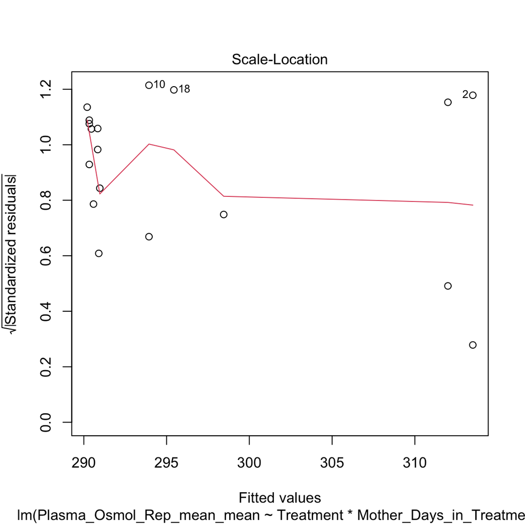

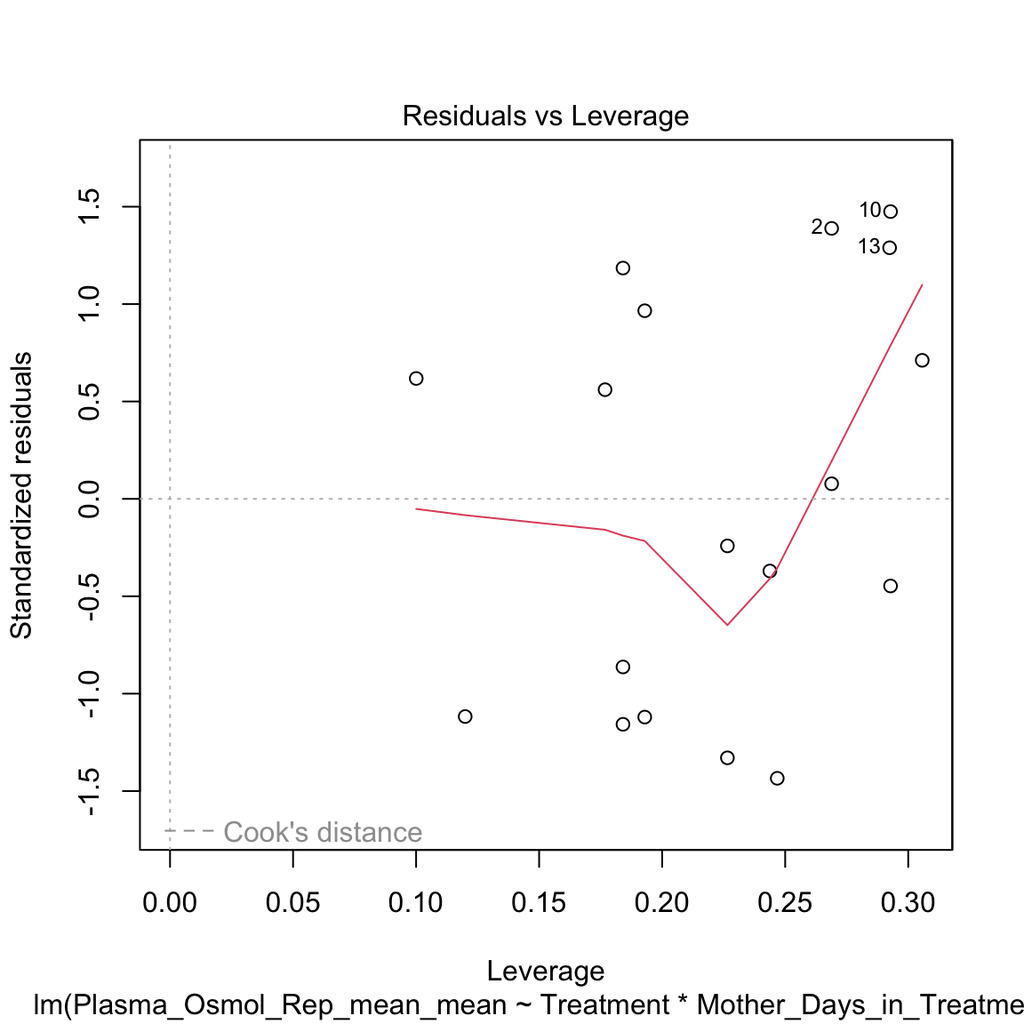

```r
plot(DAB_osml_LM_BEST_int)
```

# DAB OSML DIFFS

```r
DAB_OSMOL_LMM_1 <- lme4::lmer(data = dab_all,
                      Plasma_Osmol_Rep_mean ~
                      Treatment + Mass_g +
                        (1|Mother_ID))

drop1(DAB_OSMOL_LMM_1)
```

```
## Single term deletions
##
## Model:
## Plasma_Osmol_Rep_mean ~ Treatment + Mass_g + (1 | Mother_ID)
##           npar    AIC
## <none>         654.78
## Treatment    1 658.03
## Mass_g       1 653.70
```

```r
car::Anova(DAB_OSMOL_LMM_1, test = "F", type = "2")
```

```
## Analysis of Deviance Table (Type II Wald F tests with Kenward-Roger df)
##
## Response: Plasma_Osmol_Rep_mean
##                F Df Df.res  Pr(>F)
## Treatment 5.2151  1 15.482 0.03689 *
## Mass_g    0.9971  1 36.034 0.32468
## ---
## Signif. codes:  0 '***' 0.001 '**' 0.01 '*' 0.05 '.' 0.1 ' ' 1
```

```r
DAB_OSMOL_LMM_2 <- lme4::lmer(data = dab_all,
                      Plasma_Osmol_Rep_mean ~
                      Treatment +
                        (1|Mother_ID))
```

```r
DAB_OSMOL_LMM_null <- lme4::lmer(data = dab_all,
                      Plasma_Osmol_Rep_mean ~ 1 + (1|Mother_ID))
```

## Model Selection

```r
osml_models_all <- list(DAB_OSMOL_LMM_1, DAB_OSMOL_LMM_2, DAB_OSMOL_LMM_null)

#specify model names
osml_mod_names_all <- c('model1',
                    'model2',
                    'modelnull')

#calculate AIC of each model
osml_AICc_all <- data.frame(aictab(cand.set = osml_models_all,
                                 modnames = osml_mod_names_all))
osml_AICc_all
```

```
##    Modnames K     AICc Delta_AICc    ModelLik      AICcWt    Res.LL    Cum.Wt
## 1    model1 5 645.2186  0.0000000 1.000000000 0.544877109 -317.2093 0.5448771
## 2    model2 4 645.6023  0.3836123 0.825466856 0.449777995 -318.5380 0.9946551
## 3 modelnull 3 654.4675  9.2488364 0.009809361 0.005344896 -324.0779 1.0000000
```

No difference between 1/2.

## Final Model + emmeans

```r
DAB_OSMOL_LMM_BEST <- lmerTest::lmer(data = dab_all,
                      Plasma_Osmol_Rep_mean ~
                      Treatment +
                        (1|Mother_ID))

summary(DAB_OSMOL_LMM_BEST)
```

```
## Linear mixed model fit by REML. t-tests use Satterthwaite's method [
## lmerModLmerTest]
## Formula: Plasma_Osmol_Rep_mean ~ Treatment + (1 | Mother_ID)
##    Data: dab_all
##
## REML criterion at convergence: 637.1
##
## Scaled residuals:
##     Min      1Q  Median      3Q     Max
## -2.6947 -0.4993 -0.0758  0.5834  3.3019
##
## Random effects:
##  Groups    Name        Variance Std.Dev.
##  Mother_ID (Intercept)  83.9     9.16
##  Residual              128.6    11.34
## Number of obs: 81, groups:  Mother_ID, 18
##
## Fixed effects:
##             Estimate Std. Error      df t value Pr(>|t|)
## (Intercept)  303.641      3.774  15.893  80.467   <2e-16 ***
## TreatmentW   -13.084      5.045  15.689  -2.594   0.0198 *
## ---
## Signif. codes:  0 '***' 0.001 '**' 0.01 '*' 0.05 '.' 0.1 ' ' 1
##
## Correlation of Fixed Effects:
##            (Intr)
## TreatmentW -0.748
```

```r
car::Anova(DAB_OSMOL_LMM_BEST, test = "F", type = "2")
```

```
## Analysis of Deviance Table (Type II Wald F tests with Kenward-Roger df)
##
## Response: Plasma_Osmol_Rep_mean
##                F Df Df.res Pr(>F)
## Treatment 6.7236  1 16.027 0.0196 *
## ---
## Signif. codes:  0 '***' 0.001 '**' 0.01 '*' 0.05 '.' 0.1 ' ' 1
```

```r
emmeans(DAB_OSMOL_LMM_BEST, pairwise ~ Treatment)
```

```
## $emmeans
##  Treatment emmean   SE   df lower.CL upper.CL
##  C            304 3.77 16.2      296      312
##  W            291 3.35 15.8      283      298
##
## Degrees-of-freedom method: kenward-roger
## Confidence level used: 0.95
##
## $contrasts
##  contrast estimate   SE df t.ratio p.value
##  C - W        13.1 5.05 16   2.593  0.0196
##
## Degrees-of-freedom method: kenward-roger
```

```r
DAB_OSMOL_emmeans <- emmeans(DAB_OSMOL_LMM_BEST, "Treatment")
DAB_OSMOL_emmeans_CI <- tidy(confint(DAB_OSMOL_emmeans))
```

# PUB FIG 2 DAB

## Osmolality

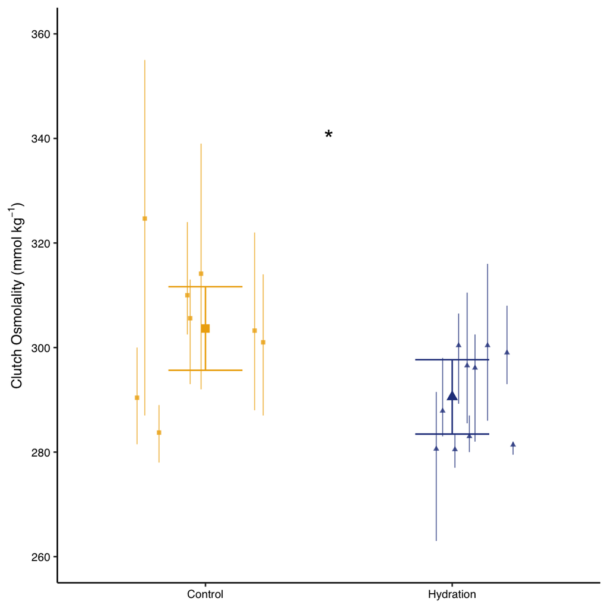

```r
ggplot() +
  geom_pointrange(
    data = dab_all_clutch_avg,
    aes(
      x = Treatment,
      y = Plasma_Osmol_Rep_mean_mean,
      ymin = Plasma_Osmol_Rep_mean_min,
      ymax = Plasma_Osmol_Rep_mean_max,
      group = Mother_ID,
      color = Treatment,
      shape = Treatment
    ),
    position = position_jitter(width = 0.3),
    size = 0.2, linewidth = 0.3,
    alpha = 0.8,
    show.legend = FALSE
  ) +
  geom_errorbar(
    data = DAB_OSMOL_emmeans_CI,
    aes(x = Treatment, ymin = conf.low, ymax = conf.high,
        color = Treatment),
    width = 0.3
  ) +
  geom_point(
    data = DAB_OSMOL_emmeans_CI,
    aes(x = Treatment, y = estimate,
        color = Treatment, shape = Treatment),
    size = 2.5
  ) +

  # prettys
  scale_color_manual(
    values = c("darkgoldenrod2", "royalblue4"),
    labels = c("C" = "Control", "W" = "Hydration"),
    name = NULL
  ) +
  scale_shape_manual(
    values = c(15, 17),
    labels = c("C" = "Control", "W" = "Hydration"),
    name = NULL
  ) +
  labs(
    x = NULL,
    y = expression('Clutch Osmolality (mmol '*kg^-1*')'),
    color = "Treatment"
  ) +
  scale_y_continuous(
    limits = c(260, 360),
    breaks = seq(260, 360, by = 20)
  ) +
  scale_x_discrete(labels = c("C" = "Control", "W" = "Hydration")) +

  theme(legend.position = "none") +

  # statistical labels
  annotate(geom = "text", x = 1.5, y = 340, label = "*", size = 6) -> dab_osml

dab_osml
```

## CEWL

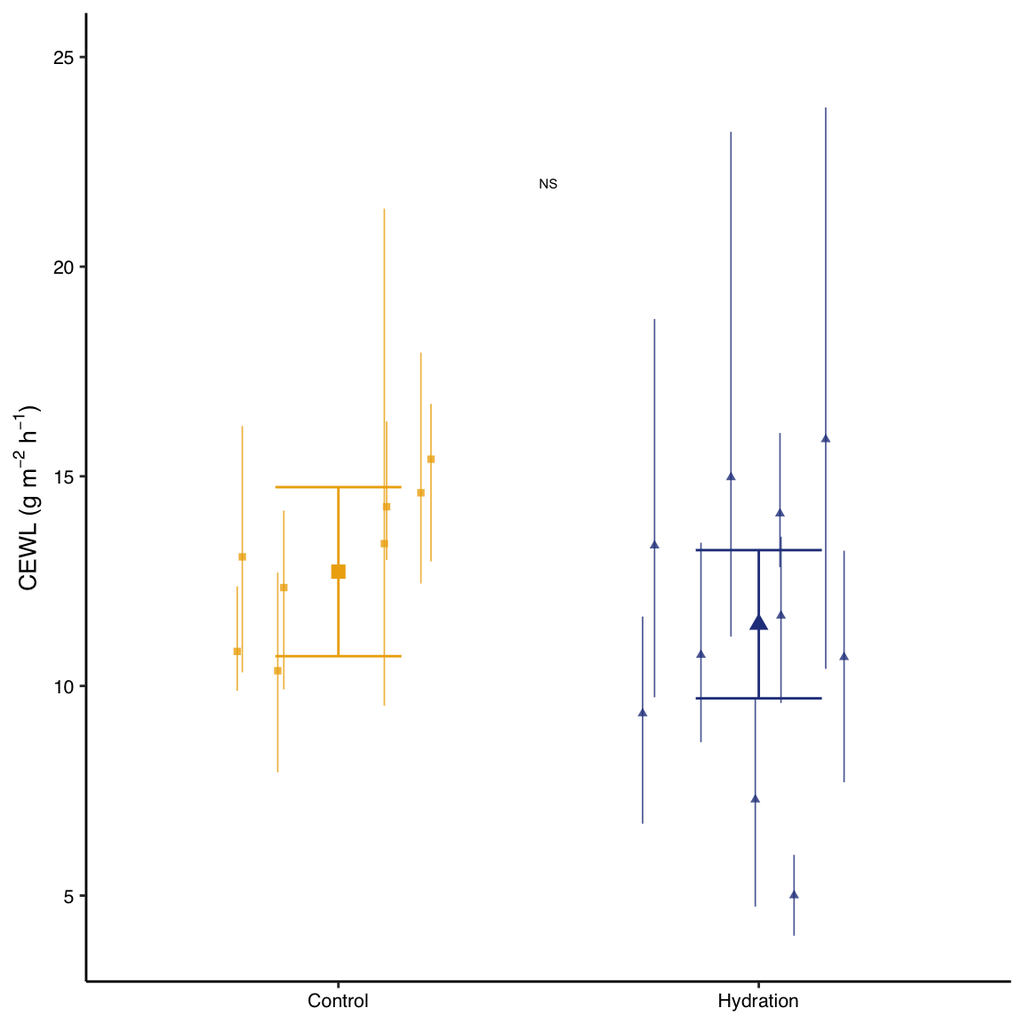

```r
ggplot() +
  geom_pointrange(
    data = dab_all_clutch_avg,
    aes(
      x = Treatment,
      y = CEWL_g_m2h_mean,
      ymin = CEWL_g_m2h_min,
      ymax = CEWL_g_m2h_max,
      group = Mother_ID,
      color = Treatment,
      shape = Treatment
    ),
    position = position_jitter(width = 0.3),
    size = 0.2, linewidth = 0.3,
    alpha = 0.8,
    show.legend = FALSE
  ) +
  geom_errorbar(
    data = DAB_CEWL_emmeans_CI,
    aes(x = Treatment, ymin = conf.low, ymax = conf.high,
        color = Treatment),
    width = 0.3
  ) +
  geom_point(
    data = DAB_CEWL_emmeans_CI,
    aes(x = Treatment, y = estimate,
        color = Treatment, shape = Treatment),
    size = 2.5
  ) +

  # prettys
  scale_color_manual(
    values = c("darkgoldenrod2", "royalblue4"),
    labels = c("C" = "Control", "W" = "Hydration"),
    name = NULL
  ) +
  scale_shape_manual(
    values = c(15, 17),
    labels = c("C" = "Control", "W" = "Hydration"),
    name = NULL
  ) +
  labs(
    x = NULL,
    y = expression('CEWL (g '*m^-2*' '*h^-1*')'),
    color = "Treatment"
  ) +
  scale_y_continuous(
    limits = c(4, 25),
    breaks = seq(0, 30, by = 5)
  ) +
  scale_x_discrete(labels = c("C" = "Control", "W" = "Hydration")) +

  theme(legend.position = "none") +

  # statistical labels
  annotate(geom = "text", x = 1.5, y = 22, label = "NS", size = 2) -> dab_cewl

dab_cewl
```

## Arrange

```r
set.seed(135) # to get a nice jitter: 10, 35, 44, 359, 135

ggarrange(
  dab_osml, dab_cewl,
  nrow = 2,
  ncol = 1,
  labels = c("A", "B"),
  align = "hv"
) -> dab_diffs

ggsave(
  filename = "Fig_neonate_dab_diffs.pdf",
  plot = dab_diffs,
  path = "./results_figures",
  device = "pdf",
  dpi = 600,
  units = "mm",
  width = 70,
  height = 150
)
```

# PUB FIG 3

## CEWL CLUTCH ~ MOTHER

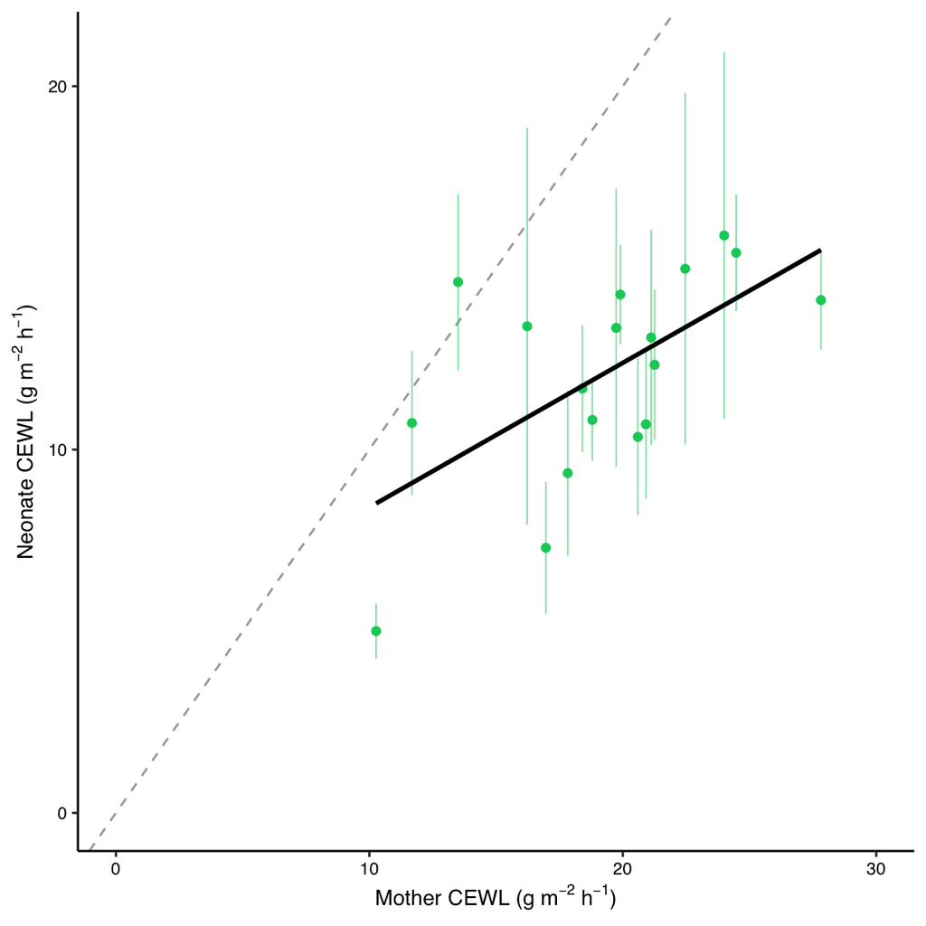

```r
ggplot(
  dab_clutch_mom,
  aes(
    x = Mother_CEWL,
    y = CEWL_g_m2h_mean
  )
) +
  geom_abline(
    slope = 1, intercept = 0,
    linetype = "dashed", color = "darkgrey"
  ) +
  geom_pointrange(
    aes(ymin = CEWL_g_m2h_mean-CEWL_g_m2h_sd,
        ymax = CEWL_g_m2h_mean+CEWL_g_m2h_sd),
    color = "springgreen3",
    alpha = 0.6, size = 0.2, linewidth = 0.3
  ) +
  geom_point(color = "springgreen3") +
  geom_smooth(
    se = F,
    formula = 'y~x',
    method = "lm",
    color = "black",
    linewidth = 1
  ) +
  scale_x_continuous(
    limits = c(0, 30),
    breaks = c(0, 10, 20, 30),
    name = expression('Mother CEWL (g '*m^-2*' '*h^-1*')')
  ) +
  scale_y_continuous(
    limits = c(0, 21),
    breaks = c(0, 10, 20),
    name = expression('Neonate CEWL (g '*m^-2*' '*h^-1*')')
  ) -> neo_mom_CEWL
neo_mom_CEWL
```

export it:

```r
ggsave(
  filename = "Fig3_neonate_mother_CEWL.pdf",
  plot = neo_mom_CEWL,
  path = "./results_figures",
  device = "pdf",
  dpi = 600,
  units = "mm",
  width = 120,
  height = 80
)
```

## OSML CLUTCH ~ MOTHER

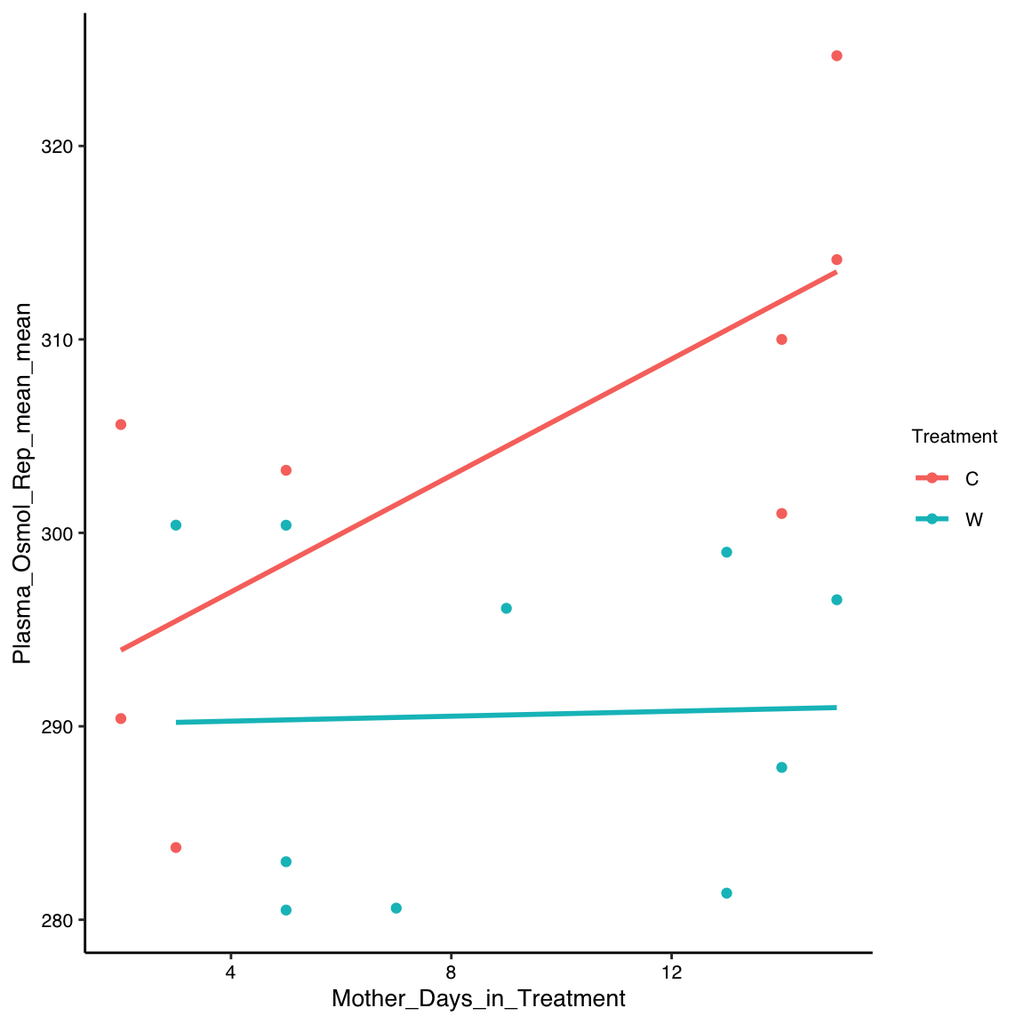

```r
ggplot(
  dab_clutch_mom,
  aes(
    x = Mother_Days_in_Treatment,
    y = Plasma_Osmol_Rep_mean_mean,
    color = Treatment
  )
) +
  geom_abline(
    slope = 1, intercept = 0,
    linetype = "dashed", color = "darkgrey"
  ) +
  geom_point() +
  geom_smooth(
    se = F,
    formula = 'y~x',
    method = "lm"
  #  color = "springgreen3"
  )
```

# TMT EFFECTS

## Calculate Deltas

Only 3 individuals were for sure measured at the before and after time points, so the change from before to after cannot be calculated for individual neonates.

```r
deltas_means <- dab_ps_compare_means %>%
  arrange(Mother_ID, timept) %>%
  group_by(Mother_ID) %>%
  mutate(
    delta_mass = Mass_g_mean - lag(Mass_g_mean),
    delta_osml = Plasma_Osmol_Rep_mean_mean - lag(Plasma_Osmol_Rep_mean_mean),
    delta_CEWL = CEWL_g_m2h_mean - lag(CEWL_g_m2h_mean)
  )

deltas_befaft <- deltas_means %>%
  ungroup() %>%
  mutate(
    delta_mass = case_when(is.na(delta_mass) ~ 0, TRUE ~ delta_mass),
    delta_osml = case_when(is.na(delta_osml) ~ 0, TRUE ~ delta_osml),
    delta_CEWL = case_when(is.na(delta_CEWL) ~ 0, TRUE ~ delta_CEWL)
  )

deltas <- deltas_means %>%
  filter(complete.cases(delta_mass))

summary(deltas_befaft)
```

```
##    Mother_ID Treatment timept        n         Tail_Length_cm_mean
##  124    :2   C:8       DAB:8   Min.   :3.000   Min.   :1.560
##  125    :2   W:8       PS :8   1st Qu.:4.750   1st Qu.:1.775
##  128    :2                     Median :5.000   Median :1.880
##  129    :2                     Mean   :4.625   Mean   :1.865
##  131    :2                     3rd Qu.:5.000   3rd Qu.:1.962
##  133    :2                     Max.   :5.000   Max.   :2.160
##  (Other):4
##   SVL_cm_mean     Mass_g_mean    Tb_CEWL_c_mean  Plasma_Osmol_Rep_mean_mean
##  Min.   :21.80   Min.   :11.66   Min.   :27.42   Min.   :280.5
##  1st Qu.:22.31   1st Qu.:13.07   1st Qu.:27.96   1st Qu.:286.2
##  Median :23.35   Median :14.14   Median :28.60   Median :296.6
##  Mean   :23.17   Mean   :14.40   Mean   :28.58   Mean   :304.2
##  3rd Qu.:23.72   3rd Qu.:15.07   3rd Qu.:29.23   3rd Qu.:312.5
##  Max.   :25.87   Max.   :18.46   Max.   :29.92   Max.   :363.4
##
##  CEWL_g_m2h_mean  msmt_temp_C_mean msmt_RH_percent_mean  VPD_kPa_mean
##  Min.   : 7.296   Min.   :23.71    Min.   :36.80        Min.   :1.595
##  1st Qu.:10.795   1st Qu.:25.40    1st Qu.:39.02        1st Qu.:1.923
##  Median :15.046   Median :25.75    Median :40.10        Median :1.962
##  Mean   :13.959   Mean   :25.65    Mean   :40.39        Mean   :1.965
##  3rd Qu.:16.193   3rd Qu.:26.01    3rd Qu.:41.24        3rd Qu.:2.060
##  Max.   :17.244   Max.   :26.88    Max.   :45.57        Max.   :2.160
##
##  Tail_Length_cm_sd   SVL_cm_sd        Mass_g_sd       Tb_CEWL_c_sd
##  Min.   :0.1517    Min.   :0.4435   Min.   :0.2380   Min.   :0.3000
##  1st Qu.:0.1930    1st Qu.:0.6132   1st Qu.:0.4584   1st Qu.:0.4959
##  Median :0.2334    Median :0.7606   Median :0.6737   Median :0.9314
##  Mean   :0.2407    Mean   :0.7866   Mean   :0.8755   Mean   :0.9654
##  3rd Qu.:0.2842    3rd Qu.:0.9680   3rd Qu.:1.2115   3rd Qu.:1.3562
##  Max.   :0.3808    Max.   :1.0970   Max.   :2.0768   Max.   :1.8050
##
##  Plasma_Osmol_Rep_mean_sd CEWL_g_m2h_sd   msmt_temp_C_sd   msmt_RH_percent_sd
##  Min.   : 2.739           Min.   :1.128   Min.   :0.1311   Min.   :0.1248
##  1st Qu.: 6.355           1st Qu.:1.765   1st Qu.:0.1642   1st Qu.:0.3391
##  Median : 8.009           Median :2.213   Median :0.1990   Median :0.6041
##  Mean   :12.556           Mean   :2.577   Mean   :0.2269   Mean   :0.8738
##  3rd Qu.:14.390           3rd Qu.:3.172   3rd Qu.:0.2876   3rd Qu.:1.2300
##  Max.   :43.634           Max.   :5.040   Max.   :0.3929   Max.   :2.6074
##
```

[output cut: 33 more lines]

```
##  Min.   :24.02   Min.   :37.77       Min.   :1.641   Min.   :-2.4800
##  1st Qu.:25.68   1st Qu.:40.20       1st Qu.:1.963   1st Qu.:-1.4400
##  Median :25.99   Median :41.31       Median :2.001   Median :-0.4100
##  Mean   :25.93   Mean   :41.46       Mean   :2.014   Mean   :-0.8094
##  3rd Qu.:26.29   3rd Qu.:42.48       3rd Qu.:2.138   3rd Qu.: 0.0000
##  Max.   :27.20   Max.   :46.22       Max.   :2.179   Max.   : 0.0000
##
##    delta_osml       delta_CEWL
##  Min.   :-18.17   Min.   :-1.215
##  1st Qu.:  0.00   1st Qu.: 0.000
##  Median :  0.00   Median : 0.000
##  Mean   : 10.75   Mean   : 2.193
##  3rd Qu.: 14.84   3rd Qu.: 5.339
##  Max.   : 72.97   Max.   : 9.816
##
```

```r
summary(deltas)
```

```
##    Mother_ID Treatment timept        n         Tail_Length_cm_mean
##  124    :1   C:4       DAB:0   Min.   :3.000   Min.   :1.680
##  125    :1   W:4       PS :8   1st Qu.:3.750   1st Qu.:1.775
##  128    :1                     Median :5.000   Median :1.890
##  129    :1                     Mean   :4.375   Mean   :1.890
##  131    :1                     3rd Qu.:5.000   3rd Qu.:1.983
##  133    :1                     Max.   :5.000   Max.   :2.160
##  (Other):2
##   SVL_cm_mean     Mass_g_mean    Tb_CEWL_c_mean  Plasma_Osmol_Rep_mean_mean
##  Min.   :23.33   Min.   :11.66   Min.   :27.47   Min.   :282.2
##  1st Qu.:23.48   1st Qu.:12.52   1st Qu.:27.75   1st Qu.:289.3
##  Median :23.64   Median :13.26   Median :28.67   Median :313.0
##  Mean   :23.94   Mean   :13.59   Mean   :28.54   Mean   :314.9
##  3rd Qu.:24.07   3rd Qu.:13.80   3rd Qu.:29.28   3rd Qu.:335.1
##  Max.   :25.87   Max.   :17.53   Max.   :29.54   Max.   :363.4
##
##  CEWL_g_m2h_mean msmt_temp_C_mean msmt_RH_percent_mean  VPD_kPa_mean
##  Min.   :14.57   Min.   :25.07    Min.   :36.80        Min.   :1.924
##  1st Qu.:15.57   1st Qu.:25.49    1st Qu.:37.87        1st Qu.:1.953
##  Median :16.34   Median :25.62    Median :39.35        Median :1.967
##  Mean   :16.15   Mean   :25.67    Mean   :39.21        Mean   :2.003
##  3rd Qu.:17.07   3rd Qu.:26.00    3rd Qu.:40.12        3rd Qu.:2.060
##  Max.   :17.24   Max.   :26.02    Max.   :41.79        Max.   :2.124
##
##  Tail_Length_cm_sd   SVL_cm_sd        Mass_g_sd       Tb_CEWL_c_sd
##  Min.   :0.1517    Min.   :0.4435   Min.   :0.2775   Min.   :0.3000
##  1st Qu.:0.1930    1st Qu.:0.5511   1st Qu.:0.4584   1st Qu.:0.4632
##  Median :0.2121    Median :0.6728   Median :0.6055   Median :0.7047
##  Mean   :0.2143    Mean   :0.7485   Mean   :0.8381   Mean   :0.7398
##  3rd Qu.:0.2255    3rd Qu.:0.9966   3rd Qu.:0.9867   3rd Qu.:0.9812
##  Max.   :0.2881    Max.   :1.0970   Max.   :1.9655   Max.   :1.2973
##
##  Plasma_Osmol_Rep_mean_sd CEWL_g_m2h_sd   msmt_temp_C_sd   msmt_RH_percent_sd
##  Min.   : 4.174           Min.   :1.595   Min.   :0.1311   Min.   :0.1248
##  1st Qu.: 7.866           1st Qu.:2.560   1st Qu.:0.1925   1st Qu.:0.3391
##  Median :11.468           Median :2.967   Median :0.2689   Median :0.5981
##  Mean   :17.693           Mean   :2.983   Mean   :0.2629   Mean   :0.8022
##  3rd Qu.:24.097           3rd Qu.:3.565   3rd Qu.:0.3181   3rd Qu.:1.2300
##  Max.   :43.634           Max.   :4.161   Max.   :0.3929   Max.   :1.7985
##
```

[output cut: 33 more lines]

```
##  Min.   :25.43   Min.   :37.77       Min.   :1.951   Min.   :-2.480
##  1st Qu.:25.82   1st Qu.:39.60       1st Qu.:1.996   1st Qu.:-2.235
##  Median :25.99   Median :40.64       Median :2.009   Median :-1.520
##  Mean   :25.96   Mean   :40.29       Mean   :2.048   Mean   :-1.619
##  3rd Qu.:26.14   3rd Qu.:41.18       3rd Qu.:2.138   3rd Qu.:-1.119
##  Max.   :26.35   Max.   :42.35       Max.   :2.149   Max.   :-0.820
##
##    delta_osml       delta_CEWL
##  Min.   :-18.17   Min.   :-1.215
##  1st Qu.:  2.30   1st Qu.: 1.772
##  Median : 19.85   Median : 5.459
##  Mean   : 21.50   Mean   : 4.387
##  3rd Qu.: 35.42   3rd Qu.: 5.942
##  Max.   : 72.97   Max.   : 9.816
##
```

## MASS

```r
mass_lm_time_tmt <- lmerTest::lmer(data = dab_ps_compare,
            Mass_g ~ timept * Treatment + (1|Mother_ID))

mass_means_time <- emmeans(mass_lm_time_tmt,
                       pairwise ~ timept | Treatment)
mass_means_time$contrasts
```

```
## Treatment = C:
##  contrast estimate    SE df t.ratio p.value
##  DAB - PS     2.16 0.319 64   6.760  <.0001
##
## Treatment = W:
##  contrast estimate    SE df t.ratio p.value
##  DAB - PS     1.08 0.339 64   3.197  0.0022
##
## Degrees-of-freedom method: kenward-roger
```

```r
mass_means_tmt <- emmeans(mass_lm_time_tmt,
                       pairwise ~ Treatment | timept)
mass_means_tmt$contrasts
```

```
## timept = DAB:
##  contrast estimate   SE   df t.ratio p.value
##  C - W       0.218 1.38 6.31   0.158  0.8798
##
## timept = PS:
##  contrast estimate   SE   df t.ratio p.value
##  C - W      -0.853 1.39 6.40  -0.614  0.5606
##
## Degrees-of-freedom method: kenward-roger
```

```r
mass_means <- emmeans(mass_lm_time_tmt, "Treatment", by = "timept")
mass_lm_time_tmt_CI <- tidy(confint(mass_means))
#mass_lm_time_tmt_CI <- tidy(mass_means_time$emmeans) # either would work

car::Anova(mass_lm_time_tmt, test = "F", type = "2")
```

```
## Analysis of Deviance Table (Type II Wald F tests with Kenward-Roger df)
##
## Response: Mass_g
##                        F Df Df.res    Pr(>F)
## timept           50.6250  1 64.025 1.166e-09 ***
## Treatment         0.0427  1  6.000   0.84314
## timept:Treatment  5.2946  1 64.027   0.02466 *
## ---
## Signif. codes:  0 '***' 0.001 '**' 0.01 '*' 0.05 '.' 0.1 ' ' 1
```

## MASS CHANGE

```r
delta_mass_lm <- lm(data = deltas, delta_mass ~ Treatment)

summary(delta_mass_lm)
```

```
##
## Call:
## lm(formula = delta_mass ~ Treatment, data = deltas)
##
## Residuals:
##      Min       1Q   Median       3Q      Max
## -0.31500 -0.15812 -0.08292  0.17250  0.48500
##
## Coefficients:
##             Estimate Std. Error t value Pr(>|t|)
## (Intercept)  -2.1650     0.1487 -14.560 6.58e-06 ***
## TreatmentW    1.0925     0.2103   5.195  0.00202 **
## ---
## Signif. codes:  0 '***' 0.001 '**' 0.01 '*' 0.05 '.' 0.1 ' ' 1
##
## Residual standard error: 0.2974 on 6 degrees of freedom
## Multiple R-squared:  0.8181, Adjusted R-squared:  0.7878
## F-statistic: 26.99 on 1 and 6 DF,  p-value: 0.002024
```

```r
car::Anova(delta_mass_lm, test = "F", type = "2")
```

```
## Anova Table (Type II tests)
##
## Response: delta_mass
##            Sum Sq Df F value   Pr(>F)
## Treatment 2.38711  1   26.99 0.002024 **
## Residuals 0.53066  6
## ---
## Signif. codes:  0 '***' 0.001 '**' 0.01 '*' 0.05 '.' 0.1 ' ' 1
```

```r
emmeans(delta_mass_lm, pairwise ~ Treatment)
```

```
## $emmeans
##  Treatment emmean    SE df lower.CL upper.CL
##  C          -2.17 0.149  6    -2.53   -1.801
##  W          -1.07 0.149  6    -1.44   -0.709
##
## Confidence level used: 0.95
##
## $contrasts
##  contrast estimate   SE df t.ratio p.value
##  C - W       -1.09 0.21  6  -5.195  0.0020
```

## OSML

```r
osml_lm_time_tmt <- lmerTest::lmer(data = dab_ps_compare,
    Plasma_Osmol_Rep_mean ~ timept * Treatment + (1|Mother_ID))

osml_means_time <- emmeans(osml_lm_time_tmt,
                       pairwise ~ timept | Treatment)
osml_means_time$contrasts
```

```
## Treatment = C:
##  contrast estimate   SE   df t.ratio p.value
##  DAB - PS   -44.98 5.30 64.2  -8.484  <.0001
##
## Treatment = W:
##  contrast estimate   SE   df t.ratio p.value
##  DAB - PS     2.46 5.63 65.0   0.436  0.6644
##
## Degrees-of-freedom method: kenward-roger
```

```r
osml_means_tmt <- emmeans(osml_lm_time_tmt,
                       pairwise ~ Treatment | timept)
osml_means_tmt$contrasts
```

```
## timept = DAB:
##  contrast estimate   SE   df t.ratio p.value
##  C - W        5.13 5.73 16.1   0.894  0.3845
##
## timept = PS:
##  contrast estimate   SE   df t.ratio p.value
##  C - W       52.56 6.06 18.6   8.680  <.0001
##
## Degrees-of-freedom method: kenward-roger
```

```r
osml_means <- emmeans(osml_lm_time_tmt, "Treatment", by = "timept")
osml_lm_time_tmt_CI <- tidy(confint(osml_means))

car::Anova(osml_lm_time_tmt, test = "F", type = "2")
```

```
## Analysis of Deviance Table (Type II Wald F tests with Kenward-Roger df)
##
## Response: Plasma_Osmol_Rep_mean
##                       F Df Df.res    Pr(>F)
## timept           34.572  1 64.631 1.582e-07 ***
## Treatment        37.853  1  5.936 0.0008798 ***
## timept:Treatment 37.601  1 64.679 5.822e-08 ***
## ---
## Signif. codes:  0 '***' 0.001 '**' 0.01 '*' 0.05 '.' 0.1 ' ' 1
```

## OSML CHANGE

```r
delta_osml_lm <- lm(data = deltas, delta_osml ~ Treatment)

summary(delta_osml_lm)
```

```
##
## Call:
## lm(formula = delta_osml ~ Treatment, data = deltas)
##
## Residuals:
##     Min      1Q  Median      3Q     Max
## -16.160 -15.311  -1.113  10.368  26.948
##
## Coefficients:
##             Estimate Std. Error t value Pr(>|t|)
## (Intercept)   46.027      8.664   5.312  0.00181 **
## TreatmentW   -49.062     12.253  -4.004  0.00709 **
## ---
## Signif. codes:  0 '***' 0.001 '**' 0.01 '*' 0.05 '.' 0.1 ' ' 1
##
## Residual standard error: 17.33 on 6 degrees of freedom
## Multiple R-squared:  0.7277, Adjusted R-squared:  0.6823
## F-statistic: 16.03 on 1 and 6 DF,  p-value: 0.007087
```

```r
car::Anova(delta_osml_lm, test = "F", type = "2")
```

```
## Anova Table (Type II tests)
##
## Response: delta_osml
##           Sum Sq Df F value   Pr(>F)
## Treatment 4814.2  1  16.032 0.007087 **
## Residuals 1801.7  6
## ---
## Signif. codes:  0 '***' 0.001 '**' 0.01 '*' 0.05 '.' 0.1 ' ' 1
```

```r
emmeans(delta_osml_lm, pairwise ~ Treatment)
```

```
## $emmeans
##  Treatment emmean   SE df lower.CL upper.CL
##  C          46.03 8.66  6     24.8     67.2
##  W          -3.04 8.66  6    -24.2     18.2
##
## Confidence level used: 0.95
##
## $contrasts
##  contrast estimate   SE df t.ratio p.value
##  C - W        49.1 12.3  6   4.004  0.0071
```

## CEWL

```r
cewl_lm_time_tmt <- lmerTest::lmer(data = dab_ps_compare,
          CEWL_g_m2h ~ timept * Treatment + (1|Mother_ID))

cewl_means_time <- emmeans(cewl_lm_time_tmt,
                       pairwise ~ timept | Treatment)
cewl_means_time$contrasts
```

```
## Treatment = C:
##  contrast estimate   SE   df t.ratio p.value
##  DAB - PS    -3.67 1.03 63.3  -3.563  0.0007
##
## Treatment = W:
##  contrast estimate   SE   df t.ratio p.value
##  DAB - PS    -4.64 1.08 63.6  -4.295  0.0001
##
## Degrees-of-freedom method: kenward-roger
```

```r
cewl_means_tmt <- emmeans(cewl_lm_time_tmt,
                       pairwise ~ Treatment | timept)
cewl_means_tmt$contrasts
```

```
## timept = DAB:
##  contrast estimate   SE   df t.ratio p.value
##  C - W       1.950 1.34 11.4   1.458  0.1718
##
## timept = PS:
##  contrast estimate   SE   df t.ratio p.value
##  C - W       0.981 1.38 12.6   0.712  0.4895
##
## Degrees-of-freedom method: kenward-roger
```

```r
cewl_means <- emmeans(cewl_lm_time_tmt, "Treatment", by = "timept")
cewl_lm_time_tmt_CI <- tidy(confint(cewl_means))

car::Anova(cewl_lm_time_tmt, test = "F", type = "2")
```

```
## Analysis of Deviance Table (Type II Wald F tests with Kenward-Roger df)
##
## Response: CEWL_g_m2h
##                        F Df Df.res    Pr(>F)
## timept           30.7227  1 63.465 6.146e-07 ***
## Treatment         1.7261  1  5.972    0.2371
## timept:Treatment  0.4205  1 63.479    0.5190
## ---
## Signif. codes:  0 '***' 0.001 '**' 0.01 '*' 0.05 '.' 0.1 ' ' 1
```

## CEWL CHANGE

```r
delta_cewl_lm <- lm(data = deltas, delta_CEWL ~ Treatment)

summary(delta_cewl_lm)
```

```
##
## Call:
## lm(formula = delta_CEWL ~ Treatment, data = deltas)
##
## Residuals:
##     Min      1Q  Median      3Q     Max
## -6.2523 -1.9639  0.7369  1.9903  4.7785
##
## Coefficients:
##             Estimate Std. Error t value Pr(>|t|)
## (Intercept)    3.736      1.825   2.047   0.0866 .
## TreatmentW     1.301      2.581   0.504   0.6322
## ---
## Signif. codes:  0 '***' 0.001 '**' 0.01 '*' 0.05 '.' 0.1 ' ' 1
##
## Residual standard error: 3.651 on 6 degrees of freedom
## Multiple R-squared:  0.04062,    Adjusted R-squared:  -0.1193
## F-statistic: 0.254 on 1 and 6 DF,  p-value: 0.6322
```

```r
car::Anova(delta_cewl_lm, test = "F", type = "2")
```

```
## Anova Table (Type II tests)
##
## Response: delta_CEWL
##           Sum Sq Df F value Pr(>F)
## Treatment  3.386  1   0.254 0.6322
## Residuals 79.967  6
```

```r
emmeans(delta_cewl_lm, pairwise ~ Treatment)
```

```
## $emmeans
##  Treatment emmean   SE df lower.CL upper.CL
##  C           3.74 1.83  6   -0.730      8.2
##  W           5.04 1.83  6    0.571      9.5
##
## Confidence level used: 0.95
##
## $contrasts
##  contrast estimate   SE df t.ratio p.value
##  C - W        -1.3 2.58  6  -0.504  0.6322
```

# PUB FIG 4

## mass raw

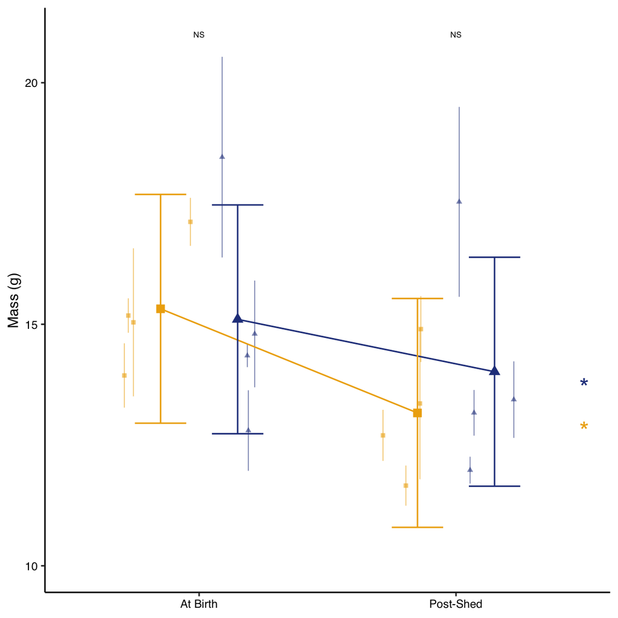

```r
ggplot() +
  geom_pointrange(
    data = dab_ps_compare_means,
    aes(
      x = timept,
      y = Mass_g_mean,
      ymin = Mass_g_mean-Mass_g_sd,
      ymax = Mass_g_mean+Mass_g_sd,
      group = Treatment,
      color = Treatment,
      shape = Treatment
    ),
    position = position_jitterdodge(jitter.width = 0.6, dodge.width = 0.6),
    size = 0.2, linewidth = 0.3,
    alpha = 0.6,
    show.legend = FALSE
  ) +
  geom_line(
    data = mass_lm_time_tmt_CI,
    aes(
      x = timept, y = estimate,
      group = Treatment,
      color = Treatment
    ),
    position = position_dodge(width = 0.6)
  ) +
  geom_errorbar(
    data = mass_lm_time_tmt_CI,
    aes(
      x = timept, y = estimate,
      ymin = conf.low, ymax = conf.high,
      group = Treatment,
      color = Treatment
    ),
    width = 0.4,
    position = position_dodge(width = 0.6)
  ) +
  geom_point(
    data = mass_lm_time_tmt_CI,
    aes(
      x = timept, y = estimate,
      group = Treatment,
      color = Treatment,
      shape = Treatment
    ),
    size = 2.5,
    position = position_dodge(width = 0.6)
  ) +

  # prettys
  scale_color_manual(
    values = c("darkgoldenrod2", "royalblue4"),
    labels = c("C" = "Control", "W" = "Hydration"),
    name = "Treatment"
  ) +
  scale_shape_manual(
    values = c(15, 17),
    labels = c("C" = "Control", "W" = "Hydration"),
    name = "Treatment"
  ) +
  scale_y_continuous(
    limits = c(10, 21),
    breaks = c(10, 15, 20),
    name = "Mass (g)"
  ) +
  scale_x_discrete(
    labels = c("DAB" = "At Birth", "PS" = "Post-Shed"),
    name = NULL
  ) +

  theme(legend.position = "none") +

  # statistical labels
  annotate(geom = "text", x = 1, y = 21, label = "NS", size = 2) +
  annotate(geom = "text", x = 2, y = 21, label = "NS", size = 2) +
  annotate(geom = "text", x = 2.5, y = 12.8, label = "*", size = 6,
           color = "darkgoldenrod2") +
  annotate(geom = "text", x = 2.5, y = 13.7, label = "*", size = 6,
           color = "royalblue4") -> neo_mass # save

neo_mass
```

## osmol raw

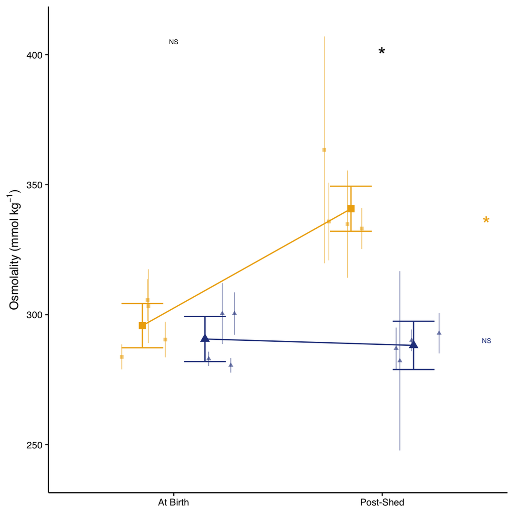

```r
ggplot() +
  geom_pointrange(
    data = dab_ps_compare_means,
    aes(
      x = timept,
      y = Plasma_Osmol_Rep_mean_mean,
      ymin = Plasma_Osmol_Rep_mean_mean-Plasma_Osmol_Rep_mean_sd,
      ymax = Plasma_Osmol_Rep_mean_mean+Plasma_Osmol_Rep_mean_sd,
      group = Treatment,
      color = Treatment,
      shape = Treatment
    ),
    position = position_jitterdodge(jitter.width = 0.6, dodge.width = 0.6),
    size = 0.2, linewidth = 0.3,
    alpha = 0.6,
    show.legend = FALSE
  ) +
  geom_line(
    data = osml_lm_time_tmt_CI,
    aes(
      x = timept, y = estimate,
      group = Treatment,
      color = Treatment
    ),
    position = position_dodge(width = 0.6)
  ) +
  geom_errorbar(
    data = osml_lm_time_tmt_CI,
    aes(
      x = timept, y = estimate,
      ymin = conf.low, ymax = conf.high,
      group = Treatment,
      color = Treatment
    ),
    width = 0.4,
    position = position_dodge(width = 0.6)
  ) +
  geom_point(
    data = osml_lm_time_tmt_CI,
    aes(
      x = timept, y = estimate,
      group = Treatment,
      color = Treatment,
      shape = Treatment
    ),
    size = 2.5,
    position = position_dodge(width = 0.6)
  ) +

  # prettys
  scale_color_manual(
    values = c("darkgoldenrod2", "royalblue4"),
    labels = c("C" = "Control", "W" = "Hydration"),
    name = "Treatment"
  ) +
  scale_shape_manual(
    values = c(15, 17),
    labels = c("C" = "Control", "W" = "Hydration"),
    name = "Treatment"
  ) +
  scale_y_continuous(
    limits = c(240, 410),
    breaks = seq(200, 400, by = 50),
    name = expression('Osmolality (mmol '*kg^-1*')'),
  ) +
  scale_x_discrete(
    labels = c("DAB" = "At Birth", "PS" = "Post-Shed"),
    name = NULL
  ) +

  theme(legend.position = "none") +

  # statistical labels
  annotate(geom = "text", x = 1, y = 405, label = "NS", size = 2) +
  annotate(geom = "text", x = 2, y = 400, label = "*", size = 6) +
  annotate(geom = "text", x = 2.5, y = 335, label = "*", size = 6,
           color = "darkgoldenrod2") +
  annotate(geom = "text", x = 2.5, y = 290, label = "NS", size = 2,
           color = "royalblue4") -> neo_osmol

neo_osmol
```

## cewl raw

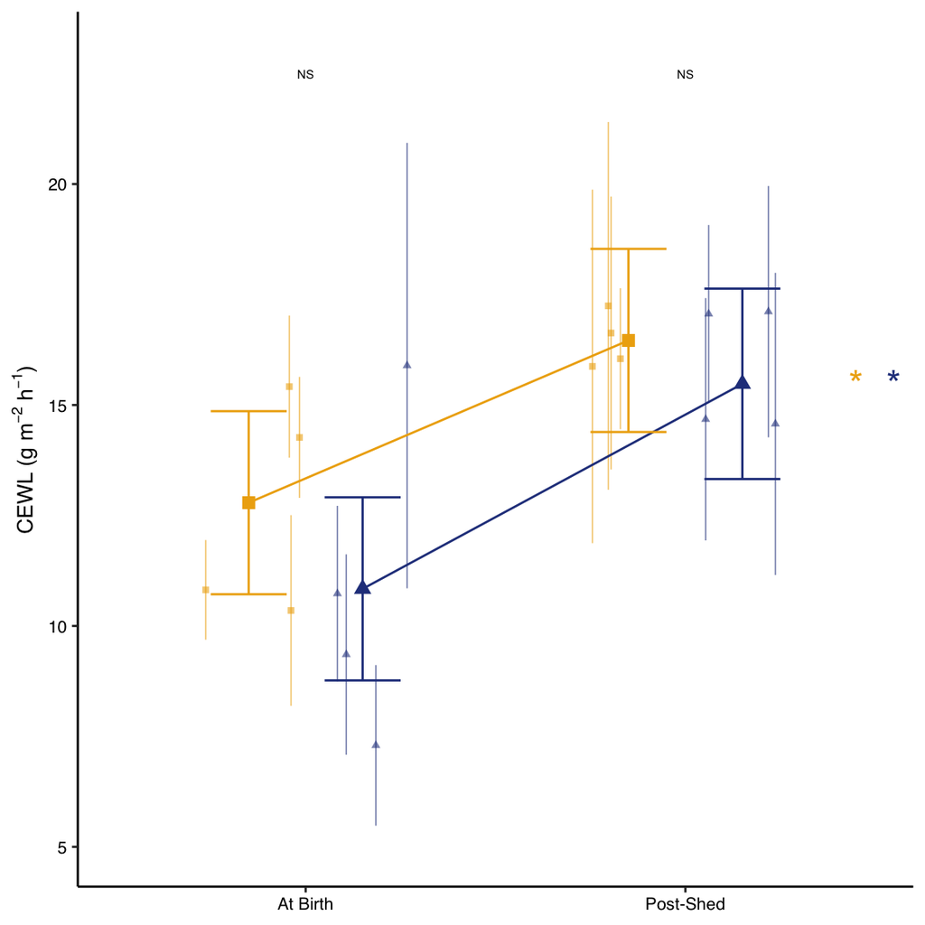

```r
ggplot() +
  geom_pointrange(
    data = dab_ps_compare_means,
    aes(
      x = timept,
      y = CEWL_g_m2h_mean,
      ymin = CEWL_g_m2h_mean-CEWL_g_m2h_sd,
      ymax = CEWL_g_m2h_mean+CEWL_g_m2h_sd,
      group = Treatment,
      color = Treatment,
      shape = Treatment
    ),
    position = position_jitterdodge(jitter.width = 0.6, dodge.width = 0.6),
    size = 0.2, linewidth = 0.3,
    alpha = 0.6,
    show.legend = FALSE
  ) +
  geom_line(
    data = cewl_lm_time_tmt_CI,
    aes(
      x = timept, y = estimate,
      group = Treatment,
      color = Treatment
    ),
    position = position_dodge(width = 0.6)
  ) +
  geom_errorbar(
    data = cewl_lm_time_tmt_CI,
    aes(
      x = timept, y = estimate,
      ymin = conf.low, ymax = conf.high,
      group = Treatment,
      color = Treatment
    ),
    width = 0.4,
    position = position_dodge(width = 0.6)
  ) +
  geom_point(
    data = cewl_lm_time_tmt_CI,
    aes(
      x = timept, y = estimate,
      group = Treatment,
      color = Treatment,
      shape = Treatment
    ),
    size = 2.5,
    position = position_dodge(width = 0.6)
  ) +

  # prettys
  scale_color_manual(
    values = c("darkgoldenrod2", "royalblue4"),
    labels = c("C" = "Control", "W" = "Hydration"),
    name = "Treatment"
  ) +
  scale_shape_manual(
    values = c(15, 17),
    labels = c("C" = "Control", "W" = "Hydration"),
    name = "Treatment"
  ) +
  scale_y_continuous(
    limits = c(5, 23),
    breaks = seq(5, 20, by = 5),
    name = expression('CEWL (g '*m^-2*' '*h^-1*')')
  ) +
  scale_x_discrete(
    labels = c("DAB" = "At Birth", "PS" = "Post-Shed"),
    name = NULL
  ) +

  theme(legend.position = "none") +

  # statistical labels
  annotate(geom = "text", x = 1, y = 22.5, label = "NS", size = 2) +
  annotate(geom = "text", x = 2, y = 22.5, label = "NS", size = 2) +
  annotate(geom = "text", x = 2.45, y = 15.5, label = "*", size = 6,
           color = "darkgoldenrod2") +
  annotate(geom = "text", x = 2.55, y = 15.5, label = "*", size = 6,
           color = "royalblue4") -> neo_cewl

neo_cewl
```

## change in mass

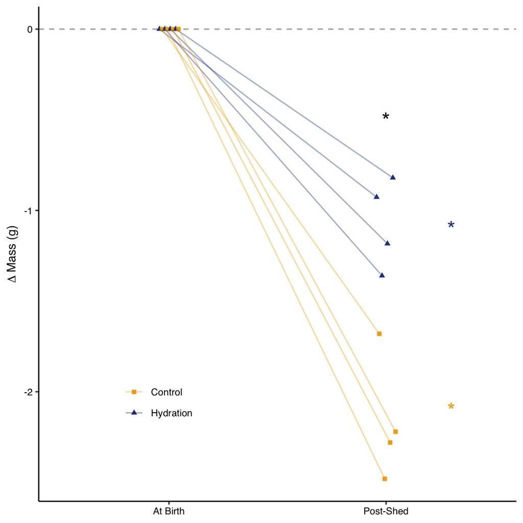

```r
ggplot(
  data = deltas_befaft,
  aes(
    x = timept,
    y = delta_mass,
    group = Mother_ID,
    color = Treatment,
    shape = Treatment
  )) +
  geom_hline(yintercept = 0, linetype = 'dashed', color = "darkgray") +
  geom_point(size = 1.4, position = position_dodge(width = 0.1)) +
  geom_line(alpha = 0.4, position = position_dodge(width = 0.1)) +

  # prettys
  scale_color_manual(
    values = c("darkgoldenrod2", "royalblue4"),
    labels = c("C" = "Control", "W" = "Hydration"),
    name = NULL
  ) +
  scale_shape_manual(
    values = c(15, 17),
    labels = c("C" = "Control", "W" = "Hydration"),
    name = NULL
  ) +
  scale_y_continuous(
    breaks = c(-3, -2, -1, 0),
    name = expression(Delta ~ 'Mass (g)')
  ) +
  scale_x_discrete(
    labels = c("DAB" = "At Birth", "PS" = "Post-Shed"),
    name = NULL
  ) +

  theme(legend.position = "inside",
        legend.position.inside = c(0.25, 0.2),
        legend.background = element_blank()) +

  # labels
  annotate(geom = "text", x = 2.3, y = -1.1, label = "*", size = 6,
           color = "royalblue4") +
  annotate(geom = "text", x = 2.3, y = -2.1, label = "*", size = 6,
           color = "darkgoldenrod2") +
  annotate(geom = "text", x = 2, y = -0.5, label = "*",
           size = 6) -> neo_change_mass
neo_change_mass
```

## change in osmol

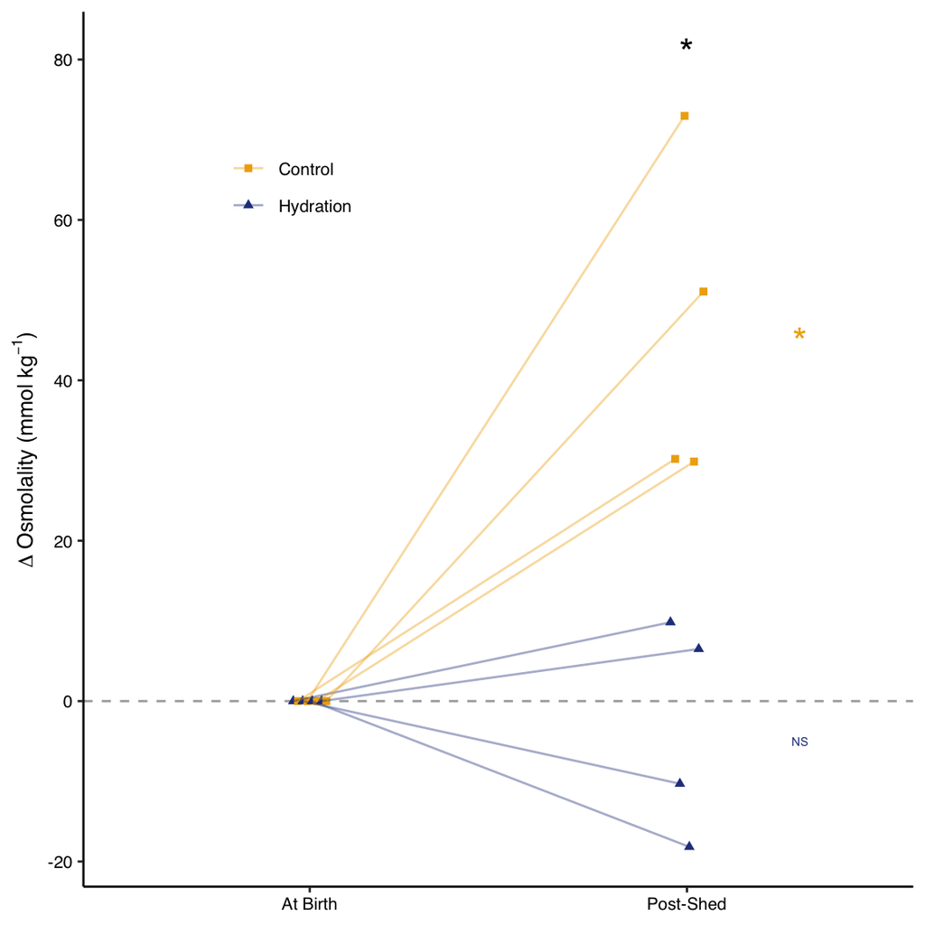

```r
ggplot(
  data = deltas_befaft,
  aes(
    x = timept,
    y = delta_osml,
    group = Mother_ID,
    color = Treatment,
    shape = Treatment
  )) +
  geom_hline(yintercept = 0, linetype = 'dashed', color = "darkgray") +
  geom_point(size = 1.4, position = position_dodge(width = 0.1)) +
  geom_line(alpha = 0.4, position = position_dodge(width = 0.1)) +

  # prettys
  scale_color_manual(
    values = c("darkgoldenrod2", "royalblue4"),
    labels = c("C" = "Control", "W" = "Hydration"),
    name = NULL
  ) +
  scale_shape_manual(
    values = c(15, 17),
    labels = c("C" = "Control", "W" = "Hydration"),
    name = NULL
  ) +
  scale_y_continuous(
    breaks = c(-20, 0, 20, 40, 60, 80),
    name = expression(Delta ~ 'Osmolality (mmol '*kg^-1*')'),
  ) +
  scale_x_discrete(
    labels = c("DAB" = "At Birth", "PS" = "Post-Shed"),
    name = NULL
  ) +

  theme(legend.position = "inside",
        legend.position.inside = c(0.25, 0.8),
        legend.background = element_blank()) +

  # labels
  annotate(geom = "text", x = 2.3, y = -5, label = "NS", size = 2,
           color = "royalblue4") +
  annotate(geom = "text", x = 2.3, y = 45, label = "*", size = 6,
           color = "darkgoldenrod2") +
  annotate(geom = "text", x = 2, y = 81, label = "*",
           size = 6) -> neo_change_osml
neo_change_osml
```

## change in cewl

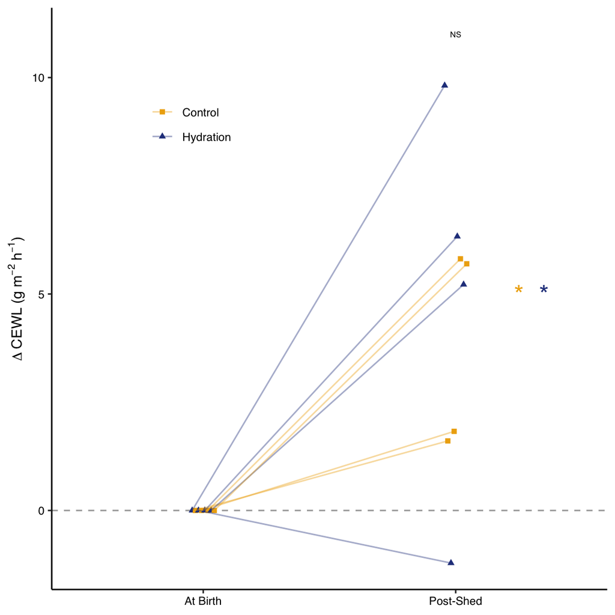

```r
ggplot(
  data = deltas_befaft,
  aes(
    x = timept,
    y = delta_CEWL,
    group = Mother_ID,
    color = Treatment,
    shape = Treatment
  )) +
  geom_hline(yintercept = 0, linetype = 'dashed', color = "darkgray") +
  geom_point(size = 1.4, position = position_dodge(width = 0.1)) +
  geom_line(alpha = 0.4, position = position_dodge(width = 0.1)) +

  # prettys
  scale_color_manual(
    values = c("darkgoldenrod2", "royalblue4"),
    labels = c("C" = "Control", "W" = "Hydration"),
    name = NULL
  ) +
  scale_shape_manual(
    values = c(15, 17),
    labels = c("C" = "Control", "W" = "Hydration"),
    name = NULL
  ) +
  scale_y_continuous(
    breaks = c(0, 5, 10),
    name = expression(Delta ~ 'CEWL (g '*m^-2*' '*h^-1*')')
  ) +
  scale_x_discrete(
    labels = c("DAB" = "At Birth", "PS" = "Post-Shed"),
    name = NULL
  ) +

  theme(legend.position = "inside",
        legend.position.inside = c(0.25, 0.8),
        legend.background = element_blank()) +

  # labels
  annotate(geom = "text", x = 2.25, y = 5, label = "*", size = 6,
           color = "darkgoldenrod2") +
  annotate(geom = "text", x = 2.35, y = 5, label = "*", size = 6,
           color = "royalblue4") +
  annotate(geom = "text", x = 2, y = 11, label = "NS",
           size = 2) -> neo_change_cewl
neo_change_cewl
```

## arrange

```r
ggarrange(
  neo_mass, neo_change_mass,
  neo_osmol, neo_change_osml,
  neo_cewl, neo_change_cewl,
  nrow = 3,
  ncol = 2,
  labels = c("A", "B", "C", "D", "E", "F"),
  align = "hv"
) -> neo_tmt_effects

ggsave(
  filename = "Fig4_neonate_tmt_effects.pdf",
  plot = neo_tmt_effects,
  path = "./results_figures",
  device = "pdf",
  dpi = 600,
  units = "mm",
  width = 150,
  height = 180
)
```